# Overview

Dataset info

| Number of variables | 81 |
| --- | --- |
| Number of observations | 1460 |
| Total Missing (%) | 5.9% |
| Total size in memory | 924.0 KiB |
| Average record size in memory | 648.1 B |

Variables types

| Numeric | 38 |
| --- | --- |
| Categorical | 43 |
| Boolean | 0 |
| Date | 0 |
| Text (Unique) | 0 |
| Rejected | 0 |
| Unsupported | 0 |

Warnings

- `2ndFlrSF` has 829 / 56.8% zeros Zeros
- `3SsnPorch` has 1436 / 98.4% zeros Zeros
- `Alley` has 1369 / 93.8% missing values Missing
- `BsmtCond` has 37 / 2.5% missing values Missing
- `BsmtExposure` has 38 / 2.6% missing values Missing
- `BsmtFinSF1` has 467 / 32.0% zeros Zeros
- `BsmtFinSF2` has 1293 / 88.6% zeros Zeros
- `BsmtFinType1` has 37 / 2.5% missing values Missing
- `BsmtFinType2` has 38 / 2.6% missing values Missing
- `BsmtFullBath` has 856 / 58.6% zeros Zeros
- `BsmtHalfBath` has 1378 / 94.4% zeros Zeros
- `BsmtQual` has 37 / 2.5% missing values Missing
- `BsmtUnfSF` has 118 / 8.1% zeros Zeros
- `EnclosedPorch` has 1252 / 85.8% zeros Zeros
- `Fence` has 1179 / 80.8% missing values Missing
- `FireplaceQu` has 690 / 47.3% missing values Missing
- `Fireplaces` has 690 / 47.3% zeros Zeros
- `GarageArea` has 81 / 5.5% zeros Zeros
- `GarageCars` has 81 / 5.5% zeros Zeros
- `GarageCond` has 81 / 5.5% missing values Missing
- `GarageFinish` has 81 / 5.5% missing values Missing
- `GarageQual` has 81 / 5.5% missing values Missing
- `GarageType` has 81 / 5.5% missing values Missing
- `GarageYrBlt` has 81 / 5.5% missing values Missing
- `HalfBath` has 913 / 62.5% zeros Zeros
- `LotFrontage` has 259 / 17.7% missing values Missing
- `LowQualFinSF` has 1434 / 98.2% zeros Zeros
- `MasVnrArea` has 861 / 59.0% zeros Zeros
- `MiscFeature` has 1406 / 96.3% missing values Missing
- `MiscVal` is highly skewed (γ1 = 24.477) Skewed
- `MiscVal` has 1408 / 96.4% zeros Zeros
- `OpenPorchSF` has 656 / 44.9% zeros Zeros
- `PoolArea` has 1453 / 99.5% zeros Zeros
- `PoolQC` has 1453 / 99.5% missing values Missing
- `ScreenPorch` has 1344 / 92.1% zeros Zeros
- `TotalBsmtSF` has 37 / 2.5% zeros Zeros
- `WoodDeckSF` has 761 / 52.1% zeros Zeros

# Variables

1stFlrSF  
Numeric

| Distinct count | 753 |
| --- | --- |
| Unique (%) | 51.6% |
| Missing (%) | 0.0% |
| Missing (n) | 0 |
| Infinite (%) | 0.0% |
| Infinite (n) | 0 |

| Mean | 1162.6 |
| --- | --- |
| Minimum | 334 |
| Maximum | 4692 |
| Zeros (%) | 0.0% |

Toggle details

**Statistics**

Quantile statistics

| Minimum | 334 |
| --- | --- |
| 5-th percentile | 672.95 |
| Q1 | 882 |
| Median | 1087 |
| Q3 | 1391.2 |
| 95-th percentile | 1831.2 |
| Maximum | 4692 |
| Range | 4358 |
| Interquartile range | 509.25 |

Descriptive statistics

| Standard deviation | 386.59 |
| --- | --- |
| Coef of variation | 0.33251 |
| Kurtosis | 5.7458 |
| Mean | 1162.6 |
| MAD | 300.58 |
| Skewness | 1.3768 |
| Sum | 1697435 |
| Variance | 149450 |
| Memory size | 11.5 KiB |

**Histogram**

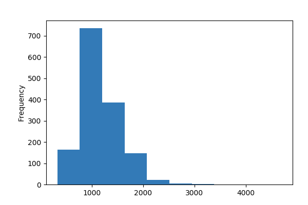

**Common Values**

| Value | Count | Frequency (%) |  |
| --- | --- | --- | --- |
| 864 | 25 | 1.7% |  |
| 1040 | 16 | 1.1% |  |
| 912 | 14 | 1.0% |  |
| 848 | 12 | 0.8% |  |
| 894 | 12 | 0.8% |  |
| 672 | 11 | 0.8% |  |
| 816 | 9 | 0.6% |  |
| 630 | 9 | 0.6% |  |
| 936 | 7 | 0.5% |  |
| 960 | 7 | 0.5% |  |
| Other values (743) | 1338 | 91.6% |  |

**Extreme Values**

Minimum 5 values

| Value | Count | Frequency (%) |  |
| --- | --- | --- | --- |
| 334 | 1 | 0.1% |  |
| 372 | 1 | 0.1% |  |
| 438 | 1 | 0.1% |  |
| 480 | 1 | 0.1% |  |
| 483 | 7 | 0.5% |  |

Maximum 5 values

| Value | Count | Frequency (%) |  |
| --- | --- | --- | --- |
| 2633 | 1 | 0.1% |  |
| 2898 | 1 | 0.1% |  |
| 3138 | 1 | 0.1% |  |
| 3228 | 1 | 0.1% |  |
| 4692 | 1 | 0.1% |  |

2ndFlrSF  
Numeric

| Distinct count | 417 |
| --- | --- |
| Unique (%) | 28.6% |
| Missing (%) | 0.0% |
| Missing (n) | 0 |
| Infinite (%) | 0.0% |
| Infinite (n) | 0 |

| Mean | 346.99 |
| --- | --- |
| Minimum | 0 |
| Maximum | 2065 |
| Zeros (%) | 56.8% |

Toggle details

**Statistics**

Quantile statistics

| Minimum | 0 |
| --- | --- |
| 5-th percentile | 0 |
| Q1 | 0 |
| Median | 0 |
| Q3 | 728 |
| 95-th percentile | 1141 |
| Maximum | 2065 |
| Range | 2065 |
| Interquartile range | 728 |

Descriptive statistics

| Standard deviation | 436.53 |
| --- | --- |
| Coef of variation | 1.258 |
| Kurtosis | -0.55346 |
| Mean | 346.99 |
| MAD | 396.48 |
| Skewness | 0.81303 |
| Sum | 506609 |
| Variance | 190560 |
| Memory size | 11.5 KiB |

**Histogram**

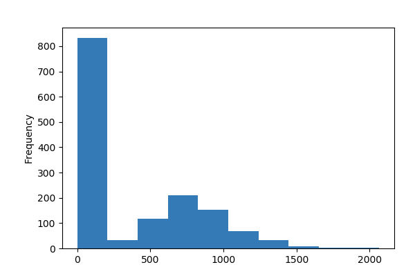

**Common Values**

| Value | Count | Frequency (%) |  |
| --- | --- | --- | --- |
| 0 | 829 | 56.8% |  |
| 728 | 10 | 0.7% |  |
| 504 | 9 | 0.6% |  |
| 672 | 8 | 0.5% |  |
| 546 | 8 | 0.5% |  |
| 720 | 7 | 0.5% |  |
| 600 | 7 | 0.5% |  |
| 896 | 6 | 0.4% |  |
| 780 | 5 | 0.3% |  |
| 862 | 5 | 0.3% |  |
| Other values (407) | 566 | 38.8% |  |

**Extreme Values**

Minimum 5 values

| Value | Count | Frequency (%) |  |
| --- | --- | --- | --- |
| 0 | 829 | 56.8% |  |
| 110 | 1 | 0.1% |  |
| 167 | 1 | 0.1% |  |
| 192 | 1 | 0.1% |  |
| 208 | 1 | 0.1% |  |

Maximum 5 values

| Value | Count | Frequency (%) |  |
| --- | --- | --- | --- |
| 1611 | 1 | 0.1% |  |
| 1796 | 1 | 0.1% |  |
| 1818 | 1 | 0.1% |  |
| 1872 | 1 | 0.1% |  |
| 2065 | 1 | 0.1% |  |

3SsnPorch  
Numeric

| Distinct count | 20 |
| --- | --- |
| Unique (%) | 1.4% |
| Missing (%) | 0.0% |
| Missing (n) | 0 |
| Infinite (%) | 0.0% |
| Infinite (n) | 0 |

| Mean | 3.4096 |
| --- | --- |
| Minimum | 0 |
| Maximum | 508 |
| Zeros (%) | 98.4% |

Toggle details

**Statistics**

Quantile statistics

| Minimum | 0 |
| --- | --- |
| 5-th percentile | 0 |
| Q1 | 0 |
| Median | 0 |
| Q3 | 0 |
| 95-th percentile | 0 |
| Maximum | 508 |
| Range | 508 |
| Interquartile range | 0 |

Descriptive statistics

| Standard deviation | 29.317 |
| --- | --- |
| Coef of variation | 8.5985 |
| Kurtosis | 123.66 |
| Mean | 3.4096 |
| MAD | 6.7071 |
| Skewness | 10.304 |
| Sum | 4978 |
| Variance | 859.51 |
| Memory size | 11.5 KiB |

**Histogram**

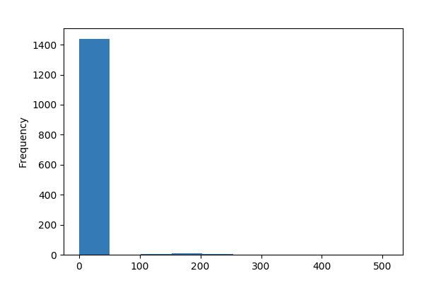

**Common Values**

| Value | Count | Frequency (%) |  |
| --- | --- | --- | --- |
| 0 | 1436 | 98.4% |  |
| 168 | 3 | 0.2% |  |
| 216 | 2 | 0.1% |  |
| 144 | 2 | 0.1% |  |
| 180 | 2 | 0.1% |  |
| 245 | 1 | 0.1% |  |
| 238 | 1 | 0.1% |  |
| 290 | 1 | 0.1% |  |
| 196 | 1 | 0.1% |  |
| 182 | 1 | 0.1% |  |
| Other values (10) | 10 | 0.7% |  |

**Extreme Values**

Minimum 5 values

| Value | Count | Frequency (%) |  |
| --- | --- | --- | --- |
| 0 | 1436 | 98.4% |  |
| 23 | 1 | 0.1% |  |
| 96 | 1 | 0.1% |  |
| 130 | 1 | 0.1% |  |
| 140 | 1 | 0.1% |  |

Maximum 5 values

| Value | Count | Frequency (%) |  |
| --- | --- | --- | --- |
| 290 | 1 | 0.1% |  |
| 304 | 1 | 0.1% |  |
| 320 | 1 | 0.1% |  |
| 407 | 1 | 0.1% |  |
| 508 | 1 | 0.1% |  |

Alley  
Categorical

| Distinct count | 3 |
| --- | --- |
| Unique (%) | 0.2% |
| Missing (%) | 93.8% |
| Missing (n) | 1369 |

| Grvl | 50 |
| --- | --- |
| Pave | 41 |
| (Missing) | 1369 |

Toggle details

| Value | Count | Frequency (%) |  |
| --- | --- | --- | --- |
| Grvl | 50 | 3.4% |  |
| Pave | 41 | 2.8% |  |
| (Missing) | 1369 | 93.8% |  |

BedroomAbvGr  
Numeric

| Distinct count | 8 |
| --- | --- |
| Unique (%) | 0.5% |
| Missing (%) | 0.0% |
| Missing (n) | 0 |
| Infinite (%) | 0.0% |
| Infinite (n) | 0 |

| Mean | 2.8664 |
| --- | --- |
| Minimum | 0 |
| Maximum | 8 |
| Zeros (%) | 0.4% |

Toggle details

**Statistics**

Quantile statistics

| Minimum | 0 |
| --- | --- |
| 5-th percentile | 2 |
| Q1 | 2 |
| Median | 3 |
| Q3 | 3 |
| 95-th percentile | 4 |
| Maximum | 8 |
| Range | 8 |
| Interquartile range | 1 |

Descriptive statistics

| Standard deviation | 0.81578 |
| --- | --- |
| Coef of variation | 0.2846 |
| Kurtosis | 2.2309 |
| Mean | 2.8664 |
| MAD | 0.57631 |
| Skewness | 0.21179 |
| Sum | 4185 |
| Variance | 0.66549 |
| Memory size | 11.5 KiB |

**Histogram**

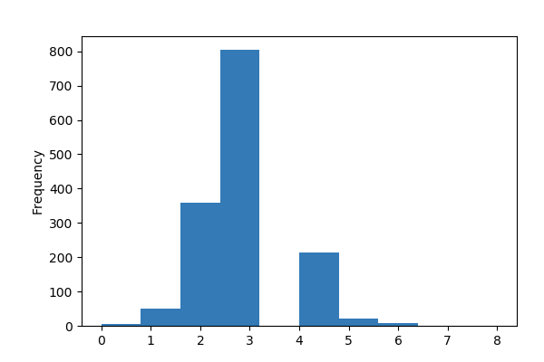

**Common Values**

| Value | Count | Frequency (%) |  |
| --- | --- | --- | --- |
| 3 | 804 | 55.1% |  |
| 2 | 358 | 24.5% |  |
| 4 | 213 | 14.6% |  |
| 1 | 50 | 3.4% |  |
| 5 | 21 | 1.4% |  |
| 6 | 7 | 0.5% |  |
| 0 | 6 | 0.4% |  |
| 8 | 1 | 0.1% |  |

**Extreme Values**

Minimum 5 values

| Value | Count | Frequency (%) |  |
| --- | --- | --- | --- |
| 0 | 6 | 0.4% |  |
| 1 | 50 | 3.4% |  |
| 2 | 358 | 24.5% |  |
| 3 | 804 | 55.1% |  |
| 4 | 213 | 14.6% |  |

Maximum 5 values

| Value | Count | Frequency (%) |  |
| --- | --- | --- | --- |
| 3 | 804 | 55.1% |  |
| 4 | 213 | 14.6% |  |
| 5 | 21 | 1.4% |  |
| 6 | 7 | 0.5% |  |
| 8 | 1 | 0.1% |  |

BldgType  
Categorical

| Distinct count | 5 |
| --- | --- |
| Unique (%) | 0.3% |
| Missing (%) | 0.0% |
| Missing (n) | 0 |

| 1Fam | 1220 |
| --- | --- |
| TwnhsE | 114 |
| Duplex | 52 |
| Other values (2) | 74 |

Toggle details

| Value | Count | Frequency (%) |  |
| --- | --- | --- | --- |
| 1Fam | 1220 | 83.6% |  |
| TwnhsE | 114 | 7.8% |  |
| Duplex | 52 | 3.6% |  |
| Twnhs | 43 | 2.9% |  |
| 2fmCon | 31 | 2.1% |  |

BsmtCond  
Categorical

| Distinct count | 5 |
| --- | --- |
| Unique (%) | 0.3% |
| Missing (%) | 2.5% |
| Missing (n) | 37 |

| TA | 1311 |
| --- | --- |
| Gd | 65 |
| Fa | 45 |
| (Missing) | 37 |

Toggle details

| Value | Count | Frequency (%) |  |
| --- | --- | --- | --- |
| TA | 1311 | 89.8% |  |
| Gd | 65 | 4.5% |  |
| Fa | 45 | 3.1% |  |
| Po | 2 | 0.1% |  |
| (Missing) | 37 | 2.5% |  |

BsmtExposure  
Categorical

| Distinct count | 5 |
| --- | --- |
| Unique (%) | 0.3% |
| Missing (%) | 2.6% |
| Missing (n) | 38 |

| No | 953 |
| --- | --- |
| Av | 221 |
| Gd | 134 |

Toggle details

| Value | Count | Frequency (%) |  |
| --- | --- | --- | --- |
| No | 953 | 65.3% |  |
| Av | 221 | 15.1% |  |
| Gd | 134 | 9.2% |  |
| Mn | 114 | 7.8% |  |
| (Missing) | 38 | 2.6% |  |

BsmtFinSF1  
Numeric

| Distinct count | 637 |
| --- | --- |
| Unique (%) | 43.6% |
| Missing (%) | 0.0% |
| Missing (n) | 0 |
| Infinite (%) | 0.0% |
| Infinite (n) | 0 |

| Mean | 443.64 |
| --- | --- |
| Minimum | 0 |
| Maximum | 5644 |
| Zeros (%) | 32.0% |

Toggle details

**Statistics**

Quantile statistics

| Minimum | 0 |
| --- | --- |
| 5-th percentile | 0 |
| Q1 | 0 |
| Median | 383.5 |
| Q3 | 712.25 |
| 95-th percentile | 1274 |
| Maximum | 5644 |
| Range | 5644 |
| Interquartile range | 712.25 |

Descriptive statistics

| Standard deviation | 456.1 |
| --- | --- |
| Coef of variation | 1.0281 |
| Kurtosis | 11.118 |
| Mean | 443.64 |
| MAD | 367.37 |
| Skewness | 1.6855 |
| Sum | 647714 |
| Variance | 208030 |
| Memory size | 11.5 KiB |

**Histogram**

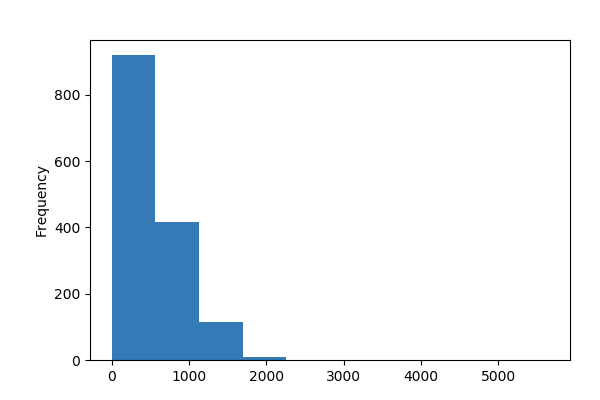

**Common Values**

| Value | Count | Frequency (%) |  |
| --- | --- | --- | --- |
| 0 | 467 | 32.0% |  |
| 24 | 12 | 0.8% |  |
| 16 | 9 | 0.6% |  |
| 20 | 5 | 0.3% |  |
| 686 | 5 | 0.3% |  |
| 616 | 5 | 0.3% |  |
| 936 | 5 | 0.3% |  |
| 662 | 5 | 0.3% |  |
| 428 | 4 | 0.3% |  |
| 655 | 4 | 0.3% |  |
| Other values (627) | 939 | 64.3% |  |

**Extreme Values**

Minimum 5 values

| Value | Count | Frequency (%) |  |
| --- | --- | --- | --- |
| 0 | 467 | 32.0% |  |
| 2 | 1 | 0.1% |  |
| 16 | 9 | 0.6% |  |
| 20 | 5 | 0.3% |  |
| 24 | 12 | 0.8% |  |

Maximum 5 values

| Value | Count | Frequency (%) |  |
| --- | --- | --- | --- |
| 1904 | 1 | 0.1% |  |
| 2096 | 1 | 0.1% |  |
| 2188 | 1 | 0.1% |  |
| 2260 | 1 | 0.1% |  |
| 5644 | 1 | 0.1% |  |

BsmtFinSF2  
Numeric

| Distinct count | 144 |
| --- | --- |
| Unique (%) | 9.9% |
| Missing (%) | 0.0% |
| Missing (n) | 0 |
| Infinite (%) | 0.0% |
| Infinite (n) | 0 |

| Mean | 46.549 |
| --- | --- |
| Minimum | 0 |
| Maximum | 1474 |
| Zeros (%) | 88.6% |

Toggle details

**Statistics**

Quantile statistics

| Minimum | 0 |
| --- | --- |
| 5-th percentile | 0 |
| Q1 | 0 |
| Median | 0 |
| Q3 | 0 |
| 95-th percentile | 396.2 |
| Maximum | 1474 |
| Range | 1474 |
| Interquartile range | 0 |

Descriptive statistics

| Standard deviation | 161.32 |
| --- | --- |
| Coef of variation | 3.4656 |
| Kurtosis | 20.113 |
| Mean | 46.549 |
| MAD | 82.535 |
| Skewness | 4.2553 |
| Sum | 67962 |
| Variance | 26024 |
| Memory size | 11.5 KiB |

**Histogram**

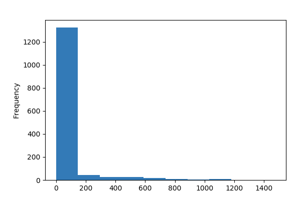

**Common Values**

| Value | Count | Frequency (%) |  |
| --- | --- | --- | --- |
| 0 | 1293 | 88.6% |  |
| 180 | 5 | 0.3% |  |
| 374 | 3 | 0.2% |  |
| 551 | 2 | 0.1% |  |
| 93 | 2 | 0.1% |  |
| 468 | 2 | 0.1% |  |
| 147 | 2 | 0.1% |  |
| 480 | 2 | 0.1% |  |
| 539 | 2 | 0.1% |  |
| 712 | 2 | 0.1% |  |
| Other values (134) | 145 | 9.9% |  |

**Extreme Values**

Minimum 5 values

| Value | Count | Frequency (%) |  |
| --- | --- | --- | --- |
| 0 | 1293 | 88.6% |  |
| 28 | 1 | 0.1% |  |
| 32 | 1 | 0.1% |  |
| 35 | 1 | 0.1% |  |
| 40 | 1 | 0.1% |  |

Maximum 5 values

| Value | Count | Frequency (%) |  |
| --- | --- | --- | --- |
| 1080 | 1 | 0.1% |  |
| 1085 | 1 | 0.1% |  |
| 1120 | 1 | 0.1% |  |
| 1127 | 1 | 0.1% |  |
| 1474 | 1 | 0.1% |  |

BsmtFinType1  
Categorical

| Distinct count | 7 |
| --- | --- |
| Unique (%) | 0.5% |
| Missing (%) | 2.5% |
| Missing (n) | 37 |

| Unf | 430 |
| --- | --- |
| GLQ | 418 |
| ALQ | 220 |
| Other values (3) | 355 |

Toggle details

| Value | Count | Frequency (%) |  |
| --- | --- | --- | --- |
| Unf | 430 | 29.5% |  |
| GLQ | 418 | 28.6% |  |
| ALQ | 220 | 15.1% |  |
| BLQ | 148 | 10.1% |  |
| Rec | 133 | 9.1% |  |
| LwQ | 74 | 5.1% |  |
| (Missing) | 37 | 2.5% |  |

BsmtFinType2  
Categorical

| Distinct count | 7 |
| --- | --- |
| Unique (%) | 0.5% |
| Missing (%) | 2.6% |
| Missing (n) | 38 |

| Unf | 1256 |
| --- | --- |
| Rec | 54 |
| LwQ | 46 |
| Other values (3) | 66 |
| (Missing) | 38 |

Toggle details

| Value | Count | Frequency (%) |  |
| --- | --- | --- | --- |
| Unf | 1256 | 86.0% |  |
| Rec | 54 | 3.7% |  |
| LwQ | 46 | 3.2% |  |
| BLQ | 33 | 2.3% |  |
| ALQ | 19 | 1.3% |  |
| GLQ | 14 | 1.0% |  |
| (Missing) | 38 | 2.6% |  |

BsmtFullBath  
Numeric

| Distinct count | 4 |
| --- | --- |
| Unique (%) | 0.3% |
| Missing (%) | 0.0% |
| Missing (n) | 0 |
| Infinite (%) | 0.0% |
| Infinite (n) | 0 |

| Mean | 0.42534 |
| --- | --- |
| Minimum | 0 |
| Maximum | 3 |
| Zeros (%) | 58.6% |

Toggle details

**Statistics**

Quantile statistics

| Minimum | 0 |
| --- | --- |
| 5-th percentile | 0 |
| Q1 | 0 |
| Median | 0 |
| Q3 | 1 |
| 95-th percentile | 1 |
| Maximum | 3 |
| Range | 3 |
| Interquartile range | 1 |

Descriptive statistics

| Standard deviation | 0.51891 |
| --- | --- |
| Coef of variation | 1.22 |
| Kurtosis | -0.8391 |
| Mean | 0.42534 |
| MAD | 0.49876 |
| Skewness | 0.59607 |
| Sum | 621 |
| Variance | 0.26927 |
| Memory size | 11.5 KiB |

**Histogram**

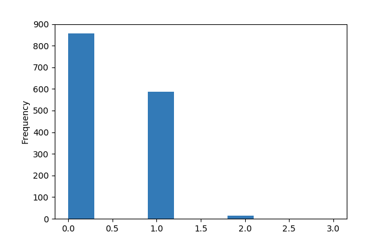

**Common Values**

| Value | Count | Frequency (%) |  |
| --- | --- | --- | --- |
| 0 | 856 | 58.6% |  |
| 1 | 588 | 40.3% |  |
| 2 | 15 | 1.0% |  |
| 3 | 1 | 0.1% |  |

**Extreme Values**

Minimum 5 values

| Value | Count | Frequency (%) |  |
| --- | --- | --- | --- |
| 0 | 856 | 58.6% |  |
| 1 | 588 | 40.3% |  |
| 2 | 15 | 1.0% |  |
| 3 | 1 | 0.1% |  |

Maximum 5 values

| Value | Count | Frequency (%) |  |
| --- | --- | --- | --- |
| 0 | 856 | 58.6% |  |
| 1 | 588 | 40.3% |  |
| 2 | 15 | 1.0% |  |
| 3 | 1 | 0.1% |  |

BsmtHalfBath  
Numeric

| Distinct count | 3 |
| --- | --- |
| Unique (%) | 0.2% |
| Missing (%) | 0.0% |
| Missing (n) | 0 |
| Infinite (%) | 0.0% |
| Infinite (n) | 0 |

| Mean | 0.057534 |
| --- | --- |
| Minimum | 0 |
| Maximum | 2 |
| Zeros (%) | 94.4% |

Toggle details

**Statistics**

Quantile statistics

| Minimum | 0 |
| --- | --- |
| 5-th percentile | 0 |
| Q1 | 0 |
| Median | 0 |
| Q3 | 0 |
| 95-th percentile | 1 |
| Maximum | 2 |
| Range | 2 |
| Interquartile range | 0 |

Descriptive statistics

| Standard deviation | 0.23875 |
| --- | --- |
| Coef of variation | 4.1497 |
| Kurtosis | 16.397 |
| Mean | 0.057534 |
| MAD | 0.10861 |
| Skewness | 4.1034 |
| Sum | 84 |
| Variance | 0.057003 |
| Memory size | 11.5 KiB |

**Histogram**

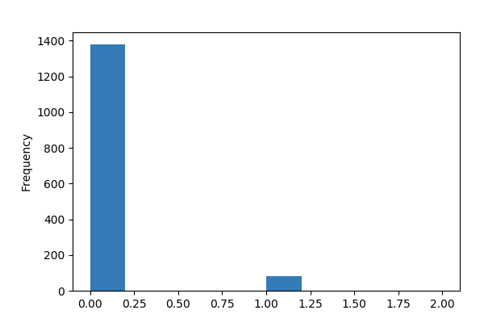

**Common Values**

| Value | Count | Frequency (%) |  |
| --- | --- | --- | --- |
| 0 | 1378 | 94.4% |  |
| 1 | 80 | 5.5% |  |
| 2 | 2 | 0.1% |  |

**Extreme Values**

Minimum 5 values

| Value | Count | Frequency (%) |  |
| --- | --- | --- | --- |
| 0 | 1378 | 94.4% |  |
| 1 | 80 | 5.5% |  |
| 2 | 2 | 0.1% |  |

Maximum 5 values

| Value | Count | Frequency (%) |  |
| --- | --- | --- | --- |
| 0 | 1378 | 94.4% |  |
| 1 | 80 | 5.5% |  |
| 2 | 2 | 0.1% |  |

BsmtQual  
Categorical

| Distinct count | 5 |
| --- | --- |
| Unique (%) | 0.3% |
| Missing (%) | 2.5% |
| Missing (n) | 37 |

| TA | 649 |
| --- | --- |
| Gd | 618 |
| Ex | 121 |
| (Missing) | 37 |

Toggle details

| Value | Count | Frequency (%) |  |
| --- | --- | --- | --- |
| TA | 649 | 44.5% |  |
| Gd | 618 | 42.3% |  |
| Ex | 121 | 8.3% |  |
| Fa | 35 | 2.4% |  |
| (Missing) | 37 | 2.5% |  |

BsmtUnfSF  
Numeric

| Distinct count | 780 |
| --- | --- |
| Unique (%) | 53.4% |
| Missing (%) | 0.0% |
| Missing (n) | 0 |
| Infinite (%) | 0.0% |
| Infinite (n) | 0 |

| Mean | 567.24 |
| --- | --- |
| Minimum | 0 |
| Maximum | 2336 |
| Zeros (%) | 8.1% |

Toggle details

**Statistics**

Quantile statistics

| Minimum | 0 |
| --- | --- |
| 5-th percentile | 0 |
| Q1 | 223 |
| Median | 477.5 |
| Q3 | 808 |
| 95-th percentile | 1468 |
| Maximum | 2336 |
| Range | 2336 |
| Interquartile range | 585 |

Descriptive statistics

| Standard deviation | 441.87 |
| --- | --- |
| Coef of variation | 0.77898 |
| Kurtosis | 0.47499 |
| Mean | 567.24 |
| MAD | 353.28 |
| Skewness | 0.92027 |
| Sum | 828171 |
| Variance | 195250 |
| Memory size | 11.5 KiB |

**Histogram**

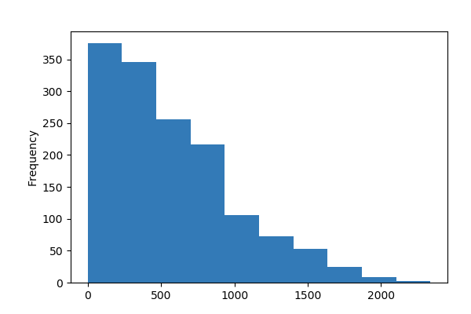

**Common Values**

| Value | Count | Frequency (%) |  |
| --- | --- | --- | --- |
| 0 | 118 | 8.1% |  |
| 728 | 9 | 0.6% |  |
| 384 | 8 | 0.5% |  |
| 572 | 7 | 0.5% |  |
| 600 | 7 | 0.5% |  |
| 300 | 7 | 0.5% |  |
| 440 | 6 | 0.4% |  |
| 625 | 6 | 0.4% |  |
| 280 | 6 | 0.4% |  |
| 672 | 6 | 0.4% |  |
| Other values (770) | 1280 | 87.7% |  |

**Extreme Values**

Minimum 5 values

| Value | Count | Frequency (%) |  |
| --- | --- | --- | --- |
| 0 | 118 | 8.1% |  |
| 14 | 1 | 0.1% |  |
| 15 | 1 | 0.1% |  |
| 23 | 2 | 0.1% |  |
| 26 | 1 | 0.1% |  |

Maximum 5 values

| Value | Count | Frequency (%) |  |
| --- | --- | --- | --- |
| 2042 | 1 | 0.1% |  |
| 2046 | 1 | 0.1% |  |
| 2121 | 1 | 0.1% |  |
| 2153 | 1 | 0.1% |  |
| 2336 | 1 | 0.1% |  |

CentralAir  
Categorical

| Distinct count | 2 |
| --- | --- |
| Unique (%) | 0.1% |
| Missing (%) | 0.0% |
| Missing (n) | 0 |

| Y | 1365 |
| --- | --- |
| N | 95 |

Toggle details

| Value | Count | Frequency (%) |  |
| --- | --- | --- | --- |
| Y | 1365 | 93.5% |  |
| N | 95 | 6.5% |  |

Condition1  
Categorical

| Distinct count | 9 |
| --- | --- |
| Unique (%) | 0.6% |
| Missing (%) | 0.0% |
| Missing (n) | 0 |

| Norm | 1260 |
| --- | --- |
| Feedr | 81 |
| Artery | 48 |
| Other values (6) | 71 |

Toggle details

| Value | Count | Frequency (%) |  |
| --- | --- | --- | --- |
| Norm | 1260 | 86.3% |  |
| Feedr | 81 | 5.5% |  |
| Artery | 48 | 3.3% |  |
| RRAn | 26 | 1.8% |  |
| PosN | 19 | 1.3% |  |
| RRAe | 11 | 0.8% |  |
| PosA | 8 | 0.5% |  |
| RRNn | 5 | 0.3% |  |
| RRNe | 2 | 0.1% |  |

Condition2  
Categorical

| Distinct count | 8 |
| --- | --- |
| Unique (%) | 0.5% |
| Missing (%) | 0.0% |
| Missing (n) | 0 |

| Norm | 1445 |
| --- | --- |
| Feedr | 6 |
| PosN | 2 |
| Other values (5) | 7 |

Toggle details

| Value | Count | Frequency (%) |  |
| --- | --- | --- | --- |
| Norm | 1445 | 99.0% |  |
| Feedr | 6 | 0.4% |  |
| PosN | 2 | 0.1% |  |
| Artery | 2 | 0.1% |  |
| RRNn | 2 | 0.1% |  |
| PosA | 1 | 0.1% |  |
| RRAe | 1 | 0.1% |  |
| RRAn | 1 | 0.1% |  |

Electrical  
Categorical

| Distinct count | 6 |
| --- | --- |
| Unique (%) | 0.4% |
| Missing (%) | 0.1% |
| Missing (n) | 1 |

| SBrkr | 1334 |
| --- | --- |
| FuseA | 94 |
| FuseF | 27 |
| Other values (2) | 4 |

Toggle details

| Value | Count | Frequency (%) |  |
| --- | --- | --- | --- |
| SBrkr | 1334 | 91.4% |  |
| FuseA | 94 | 6.4% |  |
| FuseF | 27 | 1.8% |  |
| FuseP | 3 | 0.2% |  |
| Mix | 1 | 0.1% |  |
| (Missing) | 1 | 0.1% |  |

EnclosedPorch  
Numeric

| Distinct count | 120 |
| --- | --- |
| Unique (%) | 8.2% |
| Missing (%) | 0.0% |
| Missing (n) | 0 |
| Infinite (%) | 0.0% |
| Infinite (n) | 0 |

| Mean | 21.954 |
| --- | --- |
| Minimum | 0 |
| Maximum | 552 |
| Zeros (%) | 85.8% |

Toggle details

**Statistics**

Quantile statistics

| Minimum | 0 |
| --- | --- |
| 5-th percentile | 0 |
| Q1 | 0 |
| Median | 0 |
| Q3 | 0 |
| 95-th percentile | 180.15 |
| Maximum | 552 |
| Range | 552 |
| Interquartile range | 0 |

Descriptive statistics

| Standard deviation | 61.119 |
| --- | --- |
| Coef of variation | 2.784 |
| Kurtosis | 10.431 |
| Mean | 21.954 |
| MAD | 37.66 |
| Skewness | 3.0899 |
| Sum | 32053 |
| Variance | 3735.6 |
| Memory size | 11.5 KiB |

**Histogram**

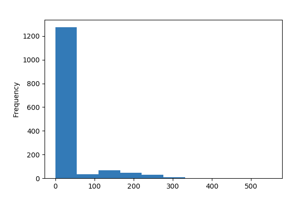

**Common Values**

| Value | Count | Frequency (%) |  |
| --- | --- | --- | --- |
| 0 | 1252 | 85.8% |  |
| 112 | 15 | 1.0% |  |
| 96 | 6 | 0.4% |  |
| 120 | 5 | 0.3% |  |
| 144 | 5 | 0.3% |  |
| 192 | 5 | 0.3% |  |
| 216 | 5 | 0.3% |  |
| 252 | 4 | 0.3% |  |
| 116 | 4 | 0.3% |  |
| 156 | 4 | 0.3% |  |
| Other values (110) | 155 | 10.6% |  |

**Extreme Values**

Minimum 5 values

| Value | Count | Frequency (%) |  |
| --- | --- | --- | --- |
| 0 | 1252 | 85.8% |  |
| 19 | 1 | 0.1% |  |
| 20 | 1 | 0.1% |  |
| 24 | 1 | 0.1% |  |
| 30 | 1 | 0.1% |  |

Maximum 5 values

| Value | Count | Frequency (%) |  |
| --- | --- | --- | --- |
| 301 | 1 | 0.1% |  |
| 318 | 1 | 0.1% |  |
| 330 | 1 | 0.1% |  |
| 386 | 1 | 0.1% |  |
| 552 | 1 | 0.1% |  |

ExterCond  
Categorical

| Distinct count | 5 |
| --- | --- |
| Unique (%) | 0.3% |
| Missing (%) | 0.0% |
| Missing (n) | 0 |

| TA | 1282 |
| --- | --- |
| Gd | 146 |
| Fa | 28 |
| Other values (2) | 4 |

Toggle details

| Value | Count | Frequency (%) |  |
| --- | --- | --- | --- |
| TA | 1282 | 87.8% |  |
| Gd | 146 | 10.0% |  |
| Fa | 28 | 1.9% |  |
| Ex | 3 | 0.2% |  |
| Po | 1 | 0.1% |  |

ExterQual  
Categorical

| Distinct count | 4 |
| --- | --- |
| Unique (%) | 0.3% |
| Missing (%) | 0.0% |
| Missing (n) | 0 |

| TA | 906 |
| --- | --- |
| Gd | 488 |
| Ex | 52 |

Toggle details

| Value | Count | Frequency (%) |  |
| --- | --- | --- | --- |
| TA | 906 | 62.1% |  |
| Gd | 488 | 33.4% |  |
| Ex | 52 | 3.6% |  |
| Fa | 14 | 1.0% |  |

Exterior1st  
Categorical

| Distinct count | 15 |
| --- | --- |
| Unique (%) | 1.0% |
| Missing (%) | 0.0% |
| Missing (n) | 0 |

| VinylSd | 515 |
| --- | --- |
| HdBoard | 222 |
| MetalSd | 220 |
| Other values (12) | 503 |

Toggle details

| Value | Count | Frequency (%) |  |
| --- | --- | --- | --- |
| VinylSd | 515 | 35.3% |  |
| HdBoard | 222 | 15.2% |  |
| MetalSd | 220 | 15.1% |  |
| Wd Sdng | 206 | 14.1% |  |
| Plywood | 108 | 7.4% |  |
| CemntBd | 61 | 4.2% |  |
| BrkFace | 50 | 3.4% |  |
| WdShing | 26 | 1.8% |  |
| Stucco | 25 | 1.7% |  |
| AsbShng | 20 | 1.4% |  |
| Other values (5) | 7 | 0.5% |  |

Exterior2nd  
Categorical

| Distinct count | 16 |
| --- | --- |
| Unique (%) | 1.1% |
| Missing (%) | 0.0% |
| Missing (n) | 0 |

| VinylSd | 504 |
| --- | --- |
| MetalSd | 214 |
| HdBoard | 207 |
| Other values (13) | 535 |

Toggle details

| Value | Count | Frequency (%) |  |
| --- | --- | --- | --- |
| VinylSd | 504 | 34.5% |  |
| MetalSd | 214 | 14.7% |  |
| HdBoard | 207 | 14.2% |  |
| Wd Sdng | 197 | 13.5% |  |
| Plywood | 142 | 9.7% |  |
| CmentBd | 60 | 4.1% |  |
| Wd Shng | 38 | 2.6% |  |
| Stucco | 26 | 1.8% |  |
| BrkFace | 25 | 1.7% |  |
| AsbShng | 20 | 1.4% |  |
| Other values (6) | 27 | 1.8% |  |

Fence  
Categorical

| Distinct count | 5 |
| --- | --- |
| Unique (%) | 0.3% |
| Missing (%) | 80.8% |
| Missing (n) | 1179 |

| MnPrv | 157 |
| --- | --- |
| GdPrv | 59 |
| GdWo | 54 |
| (Missing) | 1179 |

Toggle details

| Value | Count | Frequency (%) |  |
| --- | --- | --- | --- |
| MnPrv | 157 | 10.8% |  |
| GdPrv | 59 | 4.0% |  |
| GdWo | 54 | 3.7% |  |
| MnWw | 11 | 0.8% |  |
| (Missing) | 1179 | 80.8% |  |

FireplaceQu  
Categorical

| Distinct count | 6 |
| --- | --- |
| Unique (%) | 0.4% |
| Missing (%) | 47.3% |
| Missing (n) | 690 |

| Gd | 380 |
| --- | --- |
| TA | 313 |
| Fa | 33 |
| Other values (2) | 44 |
| (Missing) | 690 |

Toggle details

| Value | Count | Frequency (%) |  |
| --- | --- | --- | --- |
| Gd | 380 | 26.0% |  |
| TA | 313 | 21.4% |  |
| Fa | 33 | 2.3% |  |
| Ex | 24 | 1.6% |  |
| Po | 20 | 1.4% |  |
| (Missing) | 690 | 47.3% |  |

Fireplaces  
Numeric

| Distinct count | 4 |
| --- | --- |
| Unique (%) | 0.3% |
| Missing (%) | 0.0% |
| Missing (n) | 0 |
| Infinite (%) | 0.0% |
| Infinite (n) | 0 |

| Mean | 0.61301 |
| --- | --- |
| Minimum | 0 |
| Maximum | 3 |
| Zeros (%) | 47.3% |

Toggle details

**Statistics**

Quantile statistics

| Minimum | 0 |
| --- | --- |
| 5-th percentile | 0 |
| Q1 | 0 |
| Median | 1 |
| Q3 | 1 |
| 95-th percentile | 2 |
| Maximum | 3 |
| Range | 3 |
| Interquartile range | 1 |

Descriptive statistics

| Standard deviation | 0.64467 |
| --- | --- |
| Coef of variation | 1.0516 |
| Kurtosis | -0.21724 |
| Mean | 0.61301 |
| MAD | 0.57942 |
| Skewness | 0.64957 |
| Sum | 895 |
| Variance | 0.41559 |
| Memory size | 11.5 KiB |

**Histogram**

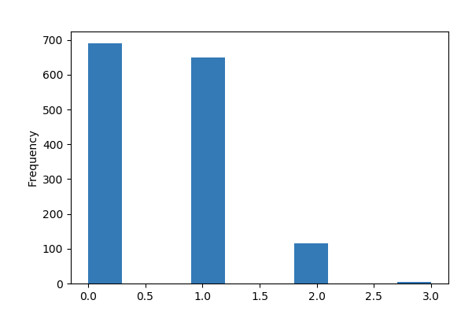

**Common Values**

| Value | Count | Frequency (%) |  |
| --- | --- | --- | --- |
| 0 | 690 | 47.3% |  |
| 1 | 650 | 44.5% |  |
| 2 | 115 | 7.9% |  |
| 3 | 5 | 0.3% |  |

**Extreme Values**

Minimum 5 values

| Value | Count | Frequency (%) |  |
| --- | --- | --- | --- |
| 0 | 690 | 47.3% |  |
| 1 | 650 | 44.5% |  |
| 2 | 115 | 7.9% |  |
| 3 | 5 | 0.3% |  |

Maximum 5 values

| Value | Count | Frequency (%) |  |
| --- | --- | --- | --- |
| 0 | 690 | 47.3% |  |
| 1 | 650 | 44.5% |  |
| 2 | 115 | 7.9% |  |
| 3 | 5 | 0.3% |  |

Foundation  
Categorical

| Distinct count | 6 |
| --- | --- |
| Unique (%) | 0.4% |
| Missing (%) | 0.0% |
| Missing (n) | 0 |

| PConc | 647 |
| --- | --- |
| CBlock | 634 |
| BrkTil | 146 |
| Other values (3) | 33 |

Toggle details

| Value | Count | Frequency (%) |  |
| --- | --- | --- | --- |
| PConc | 647 | 44.3% |  |
| CBlock | 634 | 43.4% |  |
| BrkTil | 146 | 10.0% |  |
| Slab | 24 | 1.6% |  |
| Stone | 6 | 0.4% |  |
| Wood | 3 | 0.2% |  |

FullBath  
Numeric

| Distinct count | 4 |
| --- | --- |
| Unique (%) | 0.3% |
| Missing (%) | 0.0% |
| Missing (n) | 0 |
| Infinite (%) | 0.0% |
| Infinite (n) | 0 |

| Mean | 1.5651 |
| --- | --- |
| Minimum | 0 |
| Maximum | 3 |
| Zeros (%) | 0.6% |

Toggle details

**Statistics**

Quantile statistics

| Minimum | 0 |
| --- | --- |
| 5-th percentile | 1 |
| Q1 | 1 |
| Median | 2 |
| Q3 | 2 |
| 95-th percentile | 2 |
| Maximum | 3 |
| Range | 3 |
| Interquartile range | 1 |

Descriptive statistics

| Standard deviation | 0.55092 |
| --- | --- |
| Coef of variation | 0.35201 |
| Kurtosis | -0.85704 |
| Mean | 1.5651 |
| MAD | 0.52244 |
| Skewness | 0.036562 |
| Sum | 2285 |
| Variance | 0.30351 |
| Memory size | 11.5 KiB |

**Histogram**

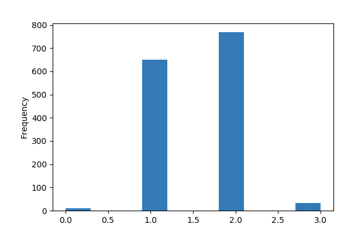

**Common Values**

| Value | Count | Frequency (%) |  |
| --- | --- | --- | --- |
| 2 | 768 | 52.6% |  |
| 1 | 650 | 44.5% |  |
| 3 | 33 | 2.3% |  |
| 0 | 9 | 0.6% |  |

**Extreme Values**

Minimum 5 values

| Value | Count | Frequency (%) |  |
| --- | --- | --- | --- |
| 0 | 9 | 0.6% |  |
| 1 | 650 | 44.5% |  |
| 2 | 768 | 52.6% |  |
| 3 | 33 | 2.3% |  |

Maximum 5 values

| Value | Count | Frequency (%) |  |
| --- | --- | --- | --- |
| 0 | 9 | 0.6% |  |
| 1 | 650 | 44.5% |  |
| 2 | 768 | 52.6% |  |
| 3 | 33 | 2.3% |  |

Functional  
Categorical

| Distinct count | 7 |
| --- | --- |
| Unique (%) | 0.5% |
| Missing (%) | 0.0% |
| Missing (n) | 0 |

| Typ | 1360 |
| --- | --- |
| Min2 | 34 |
| Min1 | 31 |
| Other values (4) | 35 |

Toggle details

| Value | Count | Frequency (%) |  |
| --- | --- | --- | --- |
| Typ | 1360 | 93.2% |  |
| Min2 | 34 | 2.3% |  |
| Min1 | 31 | 2.1% |  |
| Mod | 15 | 1.0% |  |
| Maj1 | 14 | 1.0% |  |
| Maj2 | 5 | 0.3% |  |
| Sev | 1 | 0.1% |  |

GarageArea  
Numeric

| Distinct count | 441 |
| --- | --- |
| Unique (%) | 30.2% |
| Missing (%) | 0.0% |
| Missing (n) | 0 |
| Infinite (%) | 0.0% |
| Infinite (n) | 0 |

| Mean | 472.98 |
| --- | --- |
| Minimum | 0 |
| Maximum | 1418 |
| Zeros (%) | 5.5% |

Toggle details

**Statistics**

Quantile statistics

| Minimum | 0 |
| --- | --- |
| 5-th percentile | 0 |
| Q1 | 334.5 |
| Median | 480 |
| Q3 | 576 |
| 95-th percentile | 850.1 |
| Maximum | 1418 |
| Range | 1418 |
| Interquartile range | 241.5 |

Descriptive statistics

| Standard deviation | 213.8 |
| --- | --- |
| Coef of variation | 0.45204 |
| Kurtosis | 0.91707 |
| Mean | 472.98 |
| MAD | 160.02 |
| Skewness | 0.17998 |
| Sum | 690551 |
| Variance | 45713 |
| Memory size | 11.5 KiB |

**Histogram**

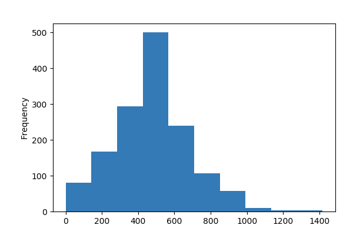

**Common Values**

| Value | Count | Frequency (%) |  |
| --- | --- | --- | --- |
| 0 | 81 | 5.5% |  |
| 440 | 49 | 3.4% |  |
| 576 | 47 | 3.2% |  |
| 240 | 38 | 2.6% |  |
| 484 | 34 | 2.3% |  |
| 528 | 33 | 2.3% |  |
| 288 | 27 | 1.8% |  |
| 400 | 25 | 1.7% |  |
| 480 | 24 | 1.6% |  |
| 264 | 24 | 1.6% |  |
| Other values (431) | 1078 | 73.8% |  |

**Extreme Values**

Minimum 5 values

| Value | Count | Frequency (%) |  |
| --- | --- | --- | --- |
| 0 | 81 | 5.5% |  |
| 160 | 2 | 0.1% |  |
| 164 | 1 | 0.1% |  |
| 180 | 9 | 0.6% |  |
| 186 | 1 | 0.1% |  |

Maximum 5 values

| Value | Count | Frequency (%) |  |
| --- | --- | --- | --- |
| 1220 | 1 | 0.1% |  |
| 1248 | 1 | 0.1% |  |
| 1356 | 1 | 0.1% |  |
| 1390 | 1 | 0.1% |  |
| 1418 | 1 | 0.1% |  |

GarageCars  
Numeric

| Distinct count | 5 |
| --- | --- |
| Unique (%) | 0.3% |
| Missing (%) | 0.0% |
| Missing (n) | 0 |
| Infinite (%) | 0.0% |
| Infinite (n) | 0 |

| Mean | 1.7671 |
| --- | --- |
| Minimum | 0 |
| Maximum | 4 |
| Zeros (%) | 5.5% |

Toggle details

**Statistics**

Quantile statistics

| Minimum | 0 |
| --- | --- |
| 5-th percentile | 0 |
| Q1 | 1 |
| Median | 2 |
| Q3 | 2 |
| 95-th percentile | 3 |
| Maximum | 4 |
| Range | 4 |
| Interquartile range | 1 |

Descriptive statistics

| Standard deviation | 0.74732 |
| --- | --- |
| Coef of variation | 0.4229 |
| Kurtosis | 0.221 |
| Mean | 1.7671 |
| MAD | 0.58384 |
| Skewness | -0.34255 |
| Sum | 2580 |
| Variance | 0.55848 |
| Memory size | 11.5 KiB |

**Histogram**

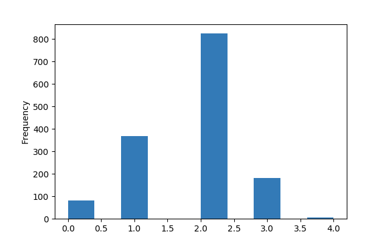

**Common Values**

| Value | Count | Frequency (%) |  |
| --- | --- | --- | --- |
| 2 | 824 | 56.4% |  |
| 1 | 369 | 25.3% |  |
| 3 | 181 | 12.4% |  |
| 0 | 81 | 5.5% |  |
| 4 | 5 | 0.3% |  |

**Extreme Values**

Minimum 5 values

| Value | Count | Frequency (%) |  |
| --- | --- | --- | --- |
| 0 | 81 | 5.5% |  |
| 1 | 369 | 25.3% |  |
| 2 | 824 | 56.4% |  |
| 3 | 181 | 12.4% |  |
| 4 | 5 | 0.3% |  |

Maximum 5 values

| Value | Count | Frequency (%) |  |
| --- | --- | --- | --- |
| 0 | 81 | 5.5% |  |
| 1 | 369 | 25.3% |  |
| 2 | 824 | 56.4% |  |
| 3 | 181 | 12.4% |  |
| 4 | 5 | 0.3% |  |

GarageCond  
Categorical

| Distinct count | 6 |
| --- | --- |
| Unique (%) | 0.4% |
| Missing (%) | 5.5% |
| Missing (n) | 81 |

| TA | 1326 |
| --- | --- |
| Fa | 35 |
| Gd | 9 |
| Other values (2) | 9 |
| (Missing) | 81 |

Toggle details

| Value | Count | Frequency (%) |  |
| --- | --- | --- | --- |
| TA | 1326 | 90.8% |  |
| Fa | 35 | 2.4% |  |
| Gd | 9 | 0.6% |  |
| Po | 7 | 0.5% |  |
| Ex | 2 | 0.1% |  |
| (Missing) | 81 | 5.5% |  |

GarageFinish  
Categorical

| Distinct count | 4 |
| --- | --- |
| Unique (%) | 0.3% |
| Missing (%) | 5.5% |
| Missing (n) | 81 |

| Unf | 605 |
| --- | --- |
| RFn | 422 |
| Fin | 352 |
| (Missing) | 81 |

Toggle details

| Value | Count | Frequency (%) |  |
| --- | --- | --- | --- |
| Unf | 605 | 41.4% |  |
| RFn | 422 | 28.9% |  |
| Fin | 352 | 24.1% |  |
| (Missing) | 81 | 5.5% |  |

GarageQual  
Categorical

| Distinct count | 6 |
| --- | --- |
| Unique (%) | 0.4% |
| Missing (%) | 5.5% |
| Missing (n) | 81 |

| TA | 1311 |
| --- | --- |
| Fa | 48 |
| Gd | 14 |
| Other values (2) | 6 |
| (Missing) | 81 |

Toggle details

| Value | Count | Frequency (%) |  |
| --- | --- | --- | --- |
| TA | 1311 | 89.8% |  |
| Fa | 48 | 3.3% |  |
| Gd | 14 | 1.0% |  |
| Po | 3 | 0.2% |  |
| Ex | 3 | 0.2% |  |
| (Missing) | 81 | 5.5% |  |

GarageType  
Categorical

| Distinct count | 7 |
| --- | --- |
| Unique (%) | 0.5% |
| Missing (%) | 5.5% |
| Missing (n) | 81 |

| Attchd | 870 |
| --- | --- |
| Detchd | 387 |
| BuiltIn | 88 |
| Other values (3) | 34 |
| (Missing) | 81 |

Toggle details

| Value | Count | Frequency (%) |  |
| --- | --- | --- | --- |
| Attchd | 870 | 59.6% |  |
| Detchd | 387 | 26.5% |  |
| BuiltIn | 88 | 6.0% |  |
| Basment | 19 | 1.3% |  |
| CarPort | 9 | 0.6% |  |
| 2Types | 6 | 0.4% |  |
| (Missing) | 81 | 5.5% |  |

GarageYrBlt  
Numeric

| Distinct count | 98 |
| --- | --- |
| Unique (%) | 6.7% |
| Missing (%) | 5.5% |
| Missing (n) | 81 |
| Infinite (%) | 0.0% |
| Infinite (n) | 0 |

| Mean | 1978.5 |
| --- | --- |
| Minimum | 1900 |
| Maximum | 2010 |
| Zeros (%) | 0.0% |

Toggle details

**Statistics**

Quantile statistics

| Minimum | 1900 |
| --- | --- |
| 5-th percentile | 1930 |
| Q1 | 1961 |
| Median | 1980 |
| Q3 | 2002 |
| 95-th percentile | 2007 |
| Maximum | 2010 |
| Range | 110 |
| Interquartile range | 41 |

Descriptive statistics

| Standard deviation | 24.69 |
| --- | --- |
| Coef of variation | 0.012479 |
| Kurtosis | -0.41834 |
| Mean | 1978.5 |
| MAD | 20.913 |
| Skewness | -0.64941 |
| Sum | 2728400 |
| Variance | 609.58 |
| Memory size | 11.5 KiB |

**Histogram**

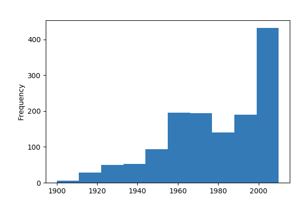

**Common Values**

| Value | Count | Frequency (%) |  |
| --- | --- | --- | --- |
| 2005.0 | 65 | 4.5% |  |
| 2006.0 | 59 | 4.0% |  |
| 2004.0 | 53 | 3.6% |  |
| 2003.0 | 50 | 3.4% |  |
| 2007.0 | 49 | 3.4% |  |
| 1977.0 | 35 | 2.4% |  |
| 1998.0 | 31 | 2.1% |  |
| 1999.0 | 30 | 2.1% |  |
| 1976.0 | 29 | 2.0% |  |
| 2008.0 | 29 | 2.0% |  |
| Other values (87) | 949 | 65.0% |  |
| (Missing) | 81 | 5.5% |  |

**Extreme Values**

Minimum 5 values

| Value | Count | Frequency (%) |  |
| --- | --- | --- | --- |
| 1900.0 | 1 | 0.1% |  |
| 1906.0 | 1 | 0.1% |  |
| 1908.0 | 1 | 0.1% |  |
| 1910.0 | 3 | 0.2% |  |
| 1914.0 | 2 | 0.1% |  |

Maximum 5 values

| Value | Count | Frequency (%) |  |
| --- | --- | --- | --- |
| 2006.0 | 59 | 4.0% |  |
| 2007.0 | 49 | 3.4% |  |
| 2008.0 | 29 | 2.0% |  |
| 2009.0 | 21 | 1.4% |  |
| 2010.0 | 3 | 0.2% |  |

GrLivArea  
Numeric

| Distinct count | 861 |
| --- | --- |
| Unique (%) | 59.0% |
| Missing (%) | 0.0% |
| Missing (n) | 0 |
| Infinite (%) | 0.0% |
| Infinite (n) | 0 |

| Mean | 1515.5 |
| --- | --- |
| Minimum | 334 |
| Maximum | 5642 |
| Zeros (%) | 0.0% |

Toggle details

**Statistics**

Quantile statistics

| Minimum | 334 |
| --- | --- |
| 5-th percentile | 848 |
| Q1 | 1129.5 |
| Median | 1464 |
| Q3 | 1776.8 |
| 95-th percentile | 2466.1 |
| Maximum | 5642 |
| Range | 5308 |
| Interquartile range | 647.25 |

Descriptive statistics

| Standard deviation | 525.48 |
| --- | --- |
| Coef of variation | 0.34675 |
| Kurtosis | 4.8951 |
| Mean | 1515.5 |
| MAD | 397.32 |
| Skewness | 1.3666 |
| Sum | 2212577 |
| Variance | 276130 |
| Memory size | 11.5 KiB |

**Histogram**

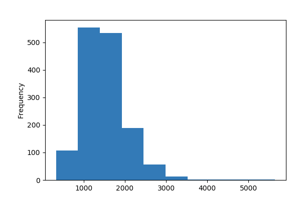

**Common Values**

| Value | Count | Frequency (%) |  |
| --- | --- | --- | --- |
| 864 | 22 | 1.5% |  |
| 1040 | 14 | 1.0% |  |
| 894 | 11 | 0.8% |  |
| 848 | 10 | 0.7% |  |
| 1456 | 10 | 0.7% |  |
| 912 | 9 | 0.6% |  |
| 1200 | 9 | 0.6% |  |
| 816 | 8 | 0.5% |  |
| 1092 | 8 | 0.5% |  |
| 1344 | 7 | 0.5% |  |
| Other values (851) | 1352 | 92.6% |  |

**Extreme Values**

Minimum 5 values

| Value | Count | Frequency (%) |  |
| --- | --- | --- | --- |
| 334 | 1 | 0.1% |  |
| 438 | 1 | 0.1% |  |
| 480 | 1 | 0.1% |  |
| 520 | 1 | 0.1% |  |
| 605 | 1 | 0.1% |  |

Maximum 5 values

| Value | Count | Frequency (%) |  |
| --- | --- | --- | --- |
| 3627 | 1 | 0.1% |  |
| 4316 | 1 | 0.1% |  |
| 4476 | 1 | 0.1% |  |
| 4676 | 1 | 0.1% |  |
| 5642 | 1 | 0.1% |  |

HalfBath  
Numeric

| Distinct count | 3 |
| --- | --- |
| Unique (%) | 0.2% |
| Missing (%) | 0.0% |
| Missing (n) | 0 |
| Infinite (%) | 0.0% |
| Infinite (n) | 0 |

| Mean | 0.38288 |
| --- | --- |
| Minimum | 0 |
| Maximum | 2 |
| Zeros (%) | 62.5% |

Toggle details

**Statistics**

Quantile statistics

| Minimum | 0 |
| --- | --- |
| 5-th percentile | 0 |
| Q1 | 0 |
| Median | 0 |
| Q3 | 1 |
| 95-th percentile | 1 |
| Maximum | 2 |
| Range | 2 |
| Interquartile range | 1 |

Descriptive statistics

| Standard deviation | 0.50289 |
| --- | --- |
| Coef of variation | 1.3134 |
| Kurtosis | -1.0769 |
| Mean | 0.38288 |
| MAD | 0.47886 |
| Skewness | 0.6759 |
| Sum | 559 |
| Variance | 0.25289 |
| Memory size | 11.5 KiB |

**Histogram**

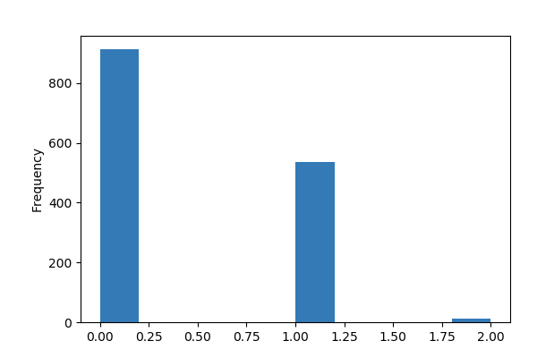

**Common Values**

| Value | Count | Frequency (%) |  |
| --- | --- | --- | --- |
| 0 | 913 | 62.5% |  |
| 1 | 535 | 36.6% |  |
| 2 | 12 | 0.8% |  |

**Extreme Values**

Minimum 5 values

| Value | Count | Frequency (%) |  |
| --- | --- | --- | --- |
| 0 | 913 | 62.5% |  |
| 1 | 535 | 36.6% |  |
| 2 | 12 | 0.8% |  |

Maximum 5 values

| Value | Count | Frequency (%) |  |
| --- | --- | --- | --- |
| 0 | 913 | 62.5% |  |
| 1 | 535 | 36.6% |  |
| 2 | 12 | 0.8% |  |

Heating  
Categorical

| Distinct count | 6 |
| --- | --- |
| Unique (%) | 0.4% |
| Missing (%) | 0.0% |
| Missing (n) | 0 |

| GasA | 1428 |
| --- | --- |
| GasW | 18 |
| Grav | 7 |
| Other values (3) | 7 |

Toggle details

| Value | Count | Frequency (%) |  |
| --- | --- | --- | --- |
| GasA | 1428 | 97.8% |  |
| GasW | 18 | 1.2% |  |
| Grav | 7 | 0.5% |  |
| Wall | 4 | 0.3% |  |
| OthW | 2 | 0.1% |  |
| Floor | 1 | 0.1% |  |

HeatingQC  
Categorical

| Distinct count | 5 |
| --- | --- |
| Unique (%) | 0.3% |
| Missing (%) | 0.0% |
| Missing (n) | 0 |

| Ex | 741 |
| --- | --- |
| TA | 428 |
| Gd | 241 |
| Other values (2) | 50 |

Toggle details

| Value | Count | Frequency (%) |  |
| --- | --- | --- | --- |
| Ex | 741 | 50.8% |  |
| TA | 428 | 29.3% |  |
| Gd | 241 | 16.5% |  |
| Fa | 49 | 3.4% |  |
| Po | 1 | 0.1% |  |

HouseStyle  
Categorical

| Distinct count | 8 |
| --- | --- |
| Unique (%) | 0.5% |
| Missing (%) | 0.0% |
| Missing (n) | 0 |

| 1Story | 726 |
| --- | --- |
| 2Story | 445 |
| 1.5Fin | 154 |
| Other values (5) | 135 |

Toggle details

| Value | Count | Frequency (%) |  |
| --- | --- | --- | --- |
| 1Story | 726 | 49.7% |  |
| 2Story | 445 | 30.5% |  |
| 1.5Fin | 154 | 10.5% |  |
| SLvl | 65 | 4.5% |  |
| SFoyer | 37 | 2.5% |  |
| 1.5Unf | 14 | 1.0% |  |
| 2.5Unf | 11 | 0.8% |  |
| 2.5Fin | 8 | 0.5% |  |

Id  
Numeric

| Distinct count | 1460 |
| --- | --- |
| Unique (%) | 100.0% |
| Missing (%) | 0.0% |
| Missing (n) | 0 |
| Infinite (%) | 0.0% |
| Infinite (n) | 0 |

| Mean | 730.5 |
| --- | --- |
| Minimum | 1 |
| Maximum | 1460 |
| Zeros (%) | 0.0% |

Toggle details

**Statistics**

Quantile statistics

| Minimum | 1 |
| --- | --- |
| 5-th percentile | 73.95 |
| Q1 | 365.75 |
| Median | 730.5 |
| Q3 | 1095.2 |
| 95-th percentile | 1387 |
| Maximum | 1460 |
| Range | 1459 |
| Interquartile range | 729.5 |

Descriptive statistics

| Standard deviation | 421.61 |
| --- | --- |
| Coef of variation | 0.57715 |
| Kurtosis | -1.2 |
| Mean | 730.5 |
| MAD | 365 |
| Skewness | 0 |
| Sum | 1066530 |
| Variance | 177760 |
| Memory size | 11.5 KiB |

**Histogram**

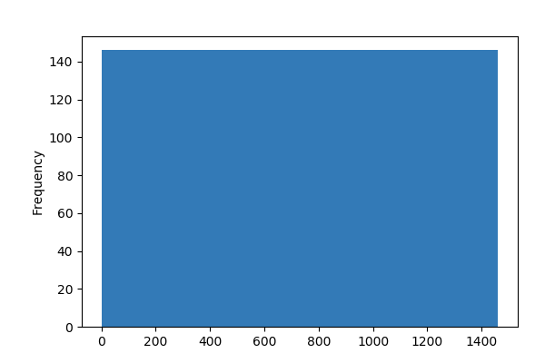

**Common Values**

| Value | Count | Frequency (%) |  |
| --- | --- | --- | --- |
| 1460 | 1 | 0.1% |  |
| 479 | 1 | 0.1% |  |
| 481 | 1 | 0.1% |  |
| 482 | 1 | 0.1% |  |
| 483 | 1 | 0.1% |  |
| 484 | 1 | 0.1% |  |
| 485 | 1 | 0.1% |  |
| 486 | 1 | 0.1% |  |
| 487 | 1 | 0.1% |  |
| 488 | 1 | 0.1% |  |
| Other values (1450) | 1450 | 99.3% |  |

**Extreme Values**

Minimum 5 values

| Value | Count | Frequency (%) |  |
| --- | --- | --- | --- |
| 1 | 1 | 0.1% |  |
| 2 | 1 | 0.1% |  |
| 3 | 1 | 0.1% |  |
| 4 | 1 | 0.1% |  |
| 5 | 1 | 0.1% |  |

Maximum 5 values

| Value | Count | Frequency (%) |  |
| --- | --- | --- | --- |
| 1456 | 1 | 0.1% |  |
| 1457 | 1 | 0.1% |  |
| 1458 | 1 | 0.1% |  |
| 1459 | 1 | 0.1% |  |
| 1460 | 1 | 0.1% |  |

KitchenAbvGr  
Numeric

| Distinct count | 4 |
| --- | --- |
| Unique (%) | 0.3% |
| Missing (%) | 0.0% |
| Missing (n) | 0 |
| Infinite (%) | 0.0% |
| Infinite (n) | 0 |

| Mean | 1.0466 |
| --- | --- |
| Minimum | 0 |
| Maximum | 3 |
| Zeros (%) | 0.1% |

Toggle details

**Statistics**

Quantile statistics

| Minimum | 0 |
| --- | --- |
| 5-th percentile | 1 |
| Q1 | 1 |
| Median | 1 |
| Q3 | 1 |
| 95-th percentile | 1 |
| Maximum | 3 |
| Range | 3 |
| Interquartile range | 0 |

Descriptive statistics

| Standard deviation | 0.22034 |
| --- | --- |
| Coef of variation | 0.21053 |
| Kurtosis | 21.532 |
| Mean | 1.0466 |
| MAD | 0.090246 |
| Skewness | 4.4884 |
| Sum | 1528 |
| Variance | 0.048549 |
| Memory size | 11.5 KiB |

**Histogram**

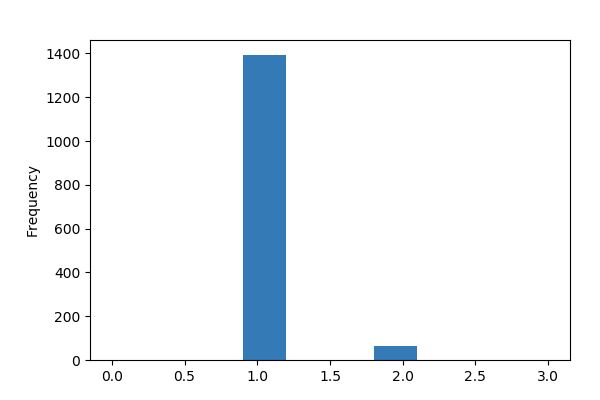

**Common Values**

| Value | Count | Frequency (%) |  |
| --- | --- | --- | --- |
| 1 | 1392 | 95.3% |  |
| 2 | 65 | 4.5% |  |
| 3 | 2 | 0.1% |  |
| 0 | 1 | 0.1% |  |

**Extreme Values**

Minimum 5 values

| Value | Count | Frequency (%) |  |
| --- | --- | --- | --- |
| 0 | 1 | 0.1% |  |
| 1 | 1392 | 95.3% |  |
| 2 | 65 | 4.5% |  |
| 3 | 2 | 0.1% |  |

Maximum 5 values

| Value | Count | Frequency (%) |  |
| --- | --- | --- | --- |
| 0 | 1 | 0.1% |  |
| 1 | 1392 | 95.3% |  |
| 2 | 65 | 4.5% |  |
| 3 | 2 | 0.1% |  |

KitchenQual  
Categorical

| Distinct count | 4 |
| --- | --- |
| Unique (%) | 0.3% |
| Missing (%) | 0.0% |
| Missing (n) | 0 |

| TA | 735 |
| --- | --- |
| Gd | 586 |
| Ex | 100 |

Toggle details

| Value | Count | Frequency (%) |  |
| --- | --- | --- | --- |
| TA | 735 | 50.3% |  |
| Gd | 586 | 40.1% |  |
| Ex | 100 | 6.8% |  |
| Fa | 39 | 2.7% |  |

LandContour  
Categorical

| Distinct count | 4 |
| --- | --- |
| Unique (%) | 0.3% |
| Missing (%) | 0.0% |
| Missing (n) | 0 |

| Lvl | 1311 |
| --- | --- |
| Bnk | 63 |
| HLS | 50 |

Toggle details

| Value | Count | Frequency (%) |  |
| --- | --- | --- | --- |
| Lvl | 1311 | 89.8% |  |
| Bnk | 63 | 4.3% |  |
| HLS | 50 | 3.4% |  |
| Low | 36 | 2.5% |  |

LandSlope  
Categorical

| Distinct count | 3 |
| --- | --- |
| Unique (%) | 0.2% |
| Missing (%) | 0.0% |
| Missing (n) | 0 |

| Gtl | 1382 |
| --- | --- |
| Mod | 65 |
| Sev | 13 |

Toggle details

| Value | Count | Frequency (%) |  |
| --- | --- | --- | --- |
| Gtl | 1382 | 94.7% |  |
| Mod | 65 | 4.5% |  |
| Sev | 13 | 0.9% |  |

LotArea  
Numeric

| Distinct count | 1073 |
| --- | --- |
| Unique (%) | 73.5% |
| Missing (%) | 0.0% |
| Missing (n) | 0 |
| Infinite (%) | 0.0% |
| Infinite (n) | 0 |

| Mean | 10517 |
| --- | --- |
| Minimum | 1300 |
| Maximum | 215245 |
| Zeros (%) | 0.0% |

Toggle details

**Statistics**

Quantile statistics

| Minimum | 1300 |
| --- | --- |
| 5-th percentile | 3311.7 |
| Q1 | 7553.5 |
| Median | 9478.5 |
| Q3 | 11602 |
| 95-th percentile | 17401 |
| Maximum | 215245 |
| Range | 213945 |
| Interquartile range | 4048 |

Descriptive statistics

| Standard deviation | 9981.3 |
| --- | --- |
| Coef of variation | 0.94908 |
| Kurtosis | 203.24 |
| Mean | 10517 |
| MAD | 3758.8 |
| Skewness | 12.208 |
| Sum | 15354569 |
| Variance | 99626000 |
| Memory size | 11.5 KiB |

**Histogram**

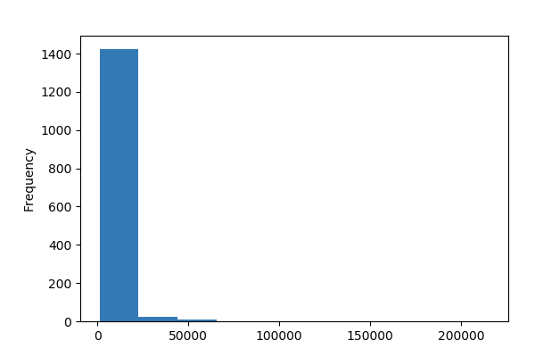

**Common Values**

| Value | Count | Frequency (%) |  |
| --- | --- | --- | --- |
| 7200 | 25 | 1.7% |  |
| 9600 | 24 | 1.6% |  |
| 6000 | 17 | 1.2% |  |
| 10800 | 14 | 1.0% |  |
| 9000 | 14 | 1.0% |  |
| 8400 | 14 | 1.0% |  |
| 1680 | 10 | 0.7% |  |
| 7500 | 9 | 0.6% |  |
| 8125 | 8 | 0.5% |  |
| 9100 | 8 | 0.5% |  |
| Other values (1063) | 1317 | 90.2% |  |

**Extreme Values**

Minimum 5 values

| Value | Count | Frequency (%) |  |
| --- | --- | --- | --- |
| 1300 | 1 | 0.1% |  |
| 1477 | 1 | 0.1% |  |
| 1491 | 1 | 0.1% |  |
| 1526 | 1 | 0.1% |  |
| 1533 | 2 | 0.1% |  |

Maximum 5 values

| Value | Count | Frequency (%) |  |
| --- | --- | --- | --- |
| 70761 | 1 | 0.1% |  |
| 115149 | 1 | 0.1% |  |
| 159000 | 1 | 0.1% |  |
| 164660 | 1 | 0.1% |  |
| 215245 | 1 | 0.1% |  |

LotConfig  
Categorical

| Distinct count | 5 |
| --- | --- |
| Unique (%) | 0.3% |
| Missing (%) | 0.0% |
| Missing (n) | 0 |

| Inside | 1052 |
| --- | --- |
| Corner | 263 |
| CulDSac | 94 |
| Other values (2) | 51 |

Toggle details

| Value | Count | Frequency (%) |  |
| --- | --- | --- | --- |
| Inside | 1052 | 72.1% |  |
| Corner | 263 | 18.0% |  |
| CulDSac | 94 | 6.4% |  |
| FR2 | 47 | 3.2% |  |
| FR3 | 4 | 0.3% |  |

LotFrontage  
Numeric

| Distinct count | 111 |
| --- | --- |
| Unique (%) | 7.6% |
| Missing (%) | 17.7% |
| Missing (n) | 259 |
| Infinite (%) | 0.0% |
| Infinite (n) | 0 |

| Mean | 70.05 |
| --- | --- |
| Minimum | 21 |
| Maximum | 313 |
| Zeros (%) | 0.0% |

Toggle details

**Statistics**

Quantile statistics

| Minimum | 21 |
| --- | --- |
| 5-th percentile | 34 |
| Q1 | 59 |
| Median | 69 |
| Q3 | 80 |
| 95-th percentile | 107 |
| Maximum | 313 |
| Range | 292 |
| Interquartile range | 21 |

Descriptive statistics

| Standard deviation | 24.285 |
| --- | --- |
| Coef of variation | 0.34668 |
| Kurtosis | 17.453 |
| Mean | 70.05 |
| MAD | 16.762 |
| Skewness | 2.1636 |
| Sum | 84130 |
| Variance | 589.75 |
| Memory size | 11.5 KiB |

**Histogram**

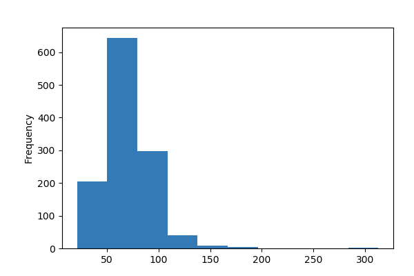

**Common Values**

| Value | Count | Frequency (%) |  |
| --- | --- | --- | --- |
| 60.0 | 143 | 9.8% |  |
| 70.0 | 70 | 4.8% |  |
| 80.0 | 69 | 4.7% |  |
| 50.0 | 57 | 3.9% |  |
| 75.0 | 53 | 3.6% |  |
| 65.0 | 44 | 3.0% |  |
| 85.0 | 40 | 2.7% |  |
| 78.0 | 25 | 1.7% |  |
| 21.0 | 23 | 1.6% |  |
| 90.0 | 23 | 1.6% |  |
| Other values (100) | 654 | 44.8% |  |
| (Missing) | 259 | 17.7% |  |

**Extreme Values**

Minimum 5 values

| Value | Count | Frequency (%) |  |
| --- | --- | --- | --- |
| 21.0 | 23 | 1.6% |  |
| 24.0 | 19 | 1.3% |  |
| 30.0 | 6 | 0.4% |  |
| 32.0 | 5 | 0.3% |  |
| 33.0 | 1 | 0.1% |  |

Maximum 5 values

| Value | Count | Frequency (%) |  |
| --- | --- | --- | --- |
| 160.0 | 1 | 0.1% |  |
| 168.0 | 1 | 0.1% |  |
| 174.0 | 2 | 0.1% |  |
| 182.0 | 1 | 0.1% |  |
| 313.0 | 2 | 0.1% |  |

LotShape  
Categorical

| Distinct count | 4 |
| --- | --- |
| Unique (%) | 0.3% |
| Missing (%) | 0.0% |
| Missing (n) | 0 |

| Reg | 925 |
| --- | --- |
| IR1 | 484 |
| IR2 | 41 |

Toggle details

| Value | Count | Frequency (%) |  |
| --- | --- | --- | --- |
| Reg | 925 | 63.4% |  |
| IR1 | 484 | 33.2% |  |
| IR2 | 41 | 2.8% |  |
| IR3 | 10 | 0.7% |  |

LowQualFinSF  
Numeric

| Distinct count | 24 |
| --- | --- |
| Unique (%) | 1.6% |
| Missing (%) | 0.0% |
| Missing (n) | 0 |
| Infinite (%) | 0.0% |
| Infinite (n) | 0 |

| Mean | 5.8445 |
| --- | --- |
| Minimum | 0 |
| Maximum | 572 |
| Zeros (%) | 98.2% |

Toggle details

**Statistics**

Quantile statistics

| Minimum | 0 |
| --- | --- |
| 5-th percentile | 0 |
| Q1 | 0 |
| Median | 0 |
| Q3 | 0 |
| 95-th percentile | 0 |
| Maximum | 572 |
| Range | 572 |
| Interquartile range | 0 |

Descriptive statistics

| Standard deviation | 48.623 |
| --- | --- |
| Coef of variation | 8.3194 |
| Kurtosis | 83.235 |
| Mean | 5.8445 |
| MAD | 11.481 |
| Skewness | 9.0113 |
| Sum | 8533 |
| Variance | 2364.2 |
| Memory size | 11.5 KiB |

**Histogram**

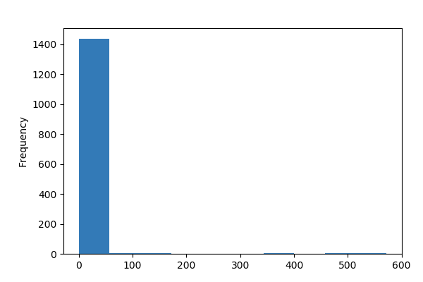

**Common Values**

| Value | Count | Frequency (%) |  |
| --- | --- | --- | --- |
| 0 | 1434 | 98.2% |  |
| 80 | 3 | 0.2% |  |
| 360 | 2 | 0.1% |  |
| 528 | 1 | 0.1% |  |
| 53 | 1 | 0.1% |  |
| 120 | 1 | 0.1% |  |
| 144 | 1 | 0.1% |  |
| 156 | 1 | 0.1% |  |
| 205 | 1 | 0.1% |  |
| 232 | 1 | 0.1% |  |
| Other values (14) | 14 | 1.0% |  |

**Extreme Values**

Minimum 5 values

| Value | Count | Frequency (%) |  |
| --- | --- | --- | --- |
| 0 | 1434 | 98.2% |  |
| 53 | 1 | 0.1% |  |
| 80 | 3 | 0.2% |  |
| 120 | 1 | 0.1% |  |
| 144 | 1 | 0.1% |  |

Maximum 5 values

| Value | Count | Frequency (%) |  |
| --- | --- | --- | --- |
| 513 | 1 | 0.1% |  |
| 514 | 1 | 0.1% |  |
| 515 | 1 | 0.1% |  |
| 528 | 1 | 0.1% |  |
| 572 | 1 | 0.1% |  |

MSSubClass  
Numeric

| Distinct count | 15 |
| --- | --- |
| Unique (%) | 1.0% |
| Missing (%) | 0.0% |
| Missing (n) | 0 |
| Infinite (%) | 0.0% |
| Infinite (n) | 0 |

| Mean | 56.897 |
| --- | --- |
| Minimum | 20 |
| Maximum | 190 |
| Zeros (%) | 0.0% |

Toggle details

**Statistics**

Quantile statistics

| Minimum | 20 |
| --- | --- |
| 5-th percentile | 20 |
| Q1 | 20 |
| Median | 50 |
| Q3 | 70 |
| 95-th percentile | 160 |
| Maximum | 190 |
| Range | 170 |
| Interquartile range | 50 |

Descriptive statistics

| Standard deviation | 42.301 |
| --- | --- |
| Coef of variation | 0.74346 |
| Kurtosis | 1.5802 |
| Mean | 56.897 |
| MAD | 31.283 |
| Skewness | 1.4077 |
| Sum | 83070 |
| Variance | 1789.3 |
| Memory size | 11.5 KiB |

**Histogram**

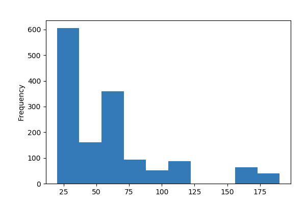

**Common Values**

| Value | Count | Frequency (%) |  |
| --- | --- | --- | --- |
| 20 | 536 | 36.7% |  |
| 60 | 299 | 20.5% |  |
| 50 | 144 | 9.9% |  |
| 120 | 87 | 6.0% |  |
| 30 | 69 | 4.7% |  |
| 160 | 63 | 4.3% |  |
| 70 | 60 | 4.1% |  |
| 80 | 58 | 4.0% |  |
| 90 | 52 | 3.6% |  |
| 190 | 30 | 2.1% |  |
| Other values (5) | 62 | 4.2% |  |

**Extreme Values**

Minimum 5 values

| Value | Count | Frequency (%) |  |
| --- | --- | --- | --- |
| 20 | 536 | 36.7% |  |
| 30 | 69 | 4.7% |  |
| 40 | 4 | 0.3% |  |
| 45 | 12 | 0.8% |  |
| 50 | 144 | 9.9% |  |

Maximum 5 values

| Value | Count | Frequency (%) |  |
| --- | --- | --- | --- |
| 90 | 52 | 3.6% |  |
| 120 | 87 | 6.0% |  |
| 160 | 63 | 4.3% |  |
| 180 | 10 | 0.7% |  |
| 190 | 30 | 2.1% |  |

MSZoning  
Categorical

| Distinct count | 5 |
| --- | --- |
| Unique (%) | 0.3% |
| Missing (%) | 0.0% |
| Missing (n) | 0 |

| RL | 1151 |
| --- | --- |
| RM | 218 |
| FV | 65 |
| Other values (2) | 26 |

Toggle details

| Value | Count | Frequency (%) |  |
| --- | --- | --- | --- |
| RL | 1151 | 78.8% |  |
| RM | 218 | 14.9% |  |
| FV | 65 | 4.5% |  |
| RH | 16 | 1.1% |  |
| C (all) | 10 | 0.7% |  |

MasVnrArea  
Numeric

| Distinct count | 328 |
| --- | --- |
| Unique (%) | 22.5% |
| Missing (%) | 0.5% |
| Missing (n) | 8 |
| Infinite (%) | 0.0% |
| Infinite (n) | 0 |

| Mean | 103.69 |
| --- | --- |
| Minimum | 0 |
| Maximum | 1600 |
| Zeros (%) | 59.0% |

Toggle details

**Statistics**

Quantile statistics

| Minimum | 0 |
| --- | --- |
| 5-th percentile | 0 |
| Q1 | 0 |
| Median | 0 |
| Q3 | 166 |
| 95-th percentile | 456 |
| Maximum | 1600 |
| Range | 1600 |
| Interquartile range | 166 |

Descriptive statistics

| Standard deviation | 181.07 |
| --- | --- |
| Coef of variation | 1.7463 |
| Kurtosis | 10.082 |
| Mean | 103.69 |
| MAD | 129.78 |
| Skewness | 2.6691 |
| Sum | 150550 |
| Variance | 32785 |
| Memory size | 11.5 KiB |

**Histogram**

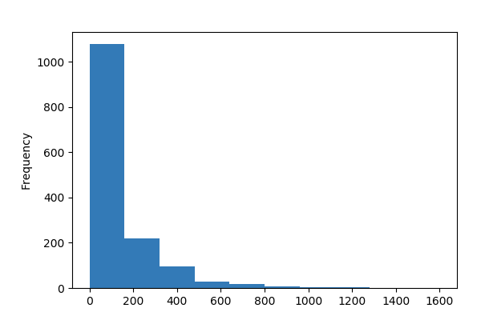

**Common Values**

| Value | Count | Frequency (%) |  |
| --- | --- | --- | --- |
| 0.0 | 861 | 59.0% |  |
| 72.0 | 8 | 0.5% |  |
| 180.0 | 8 | 0.5% |  |
| 108.0 | 8 | 0.5% |  |
| 120.0 | 7 | 0.5% |  |
| 16.0 | 7 | 0.5% |  |
| 106.0 | 6 | 0.4% |  |
| 80.0 | 6 | 0.4% |  |
| 340.0 | 6 | 0.4% |  |
| 200.0 | 6 | 0.4% |  |
| Other values (317) | 529 | 36.2% |  |
| (Missing) | 8 | 0.5% |  |

**Extreme Values**

Minimum 5 values

| Value | Count | Frequency (%) |  |
| --- | --- | --- | --- |
| 0.0 | 861 | 59.0% |  |
| 1.0 | 2 | 0.1% |  |
| 11.0 | 1 | 0.1% |  |
| 14.0 | 1 | 0.1% |  |
| 16.0 | 7 | 0.5% |  |

Maximum 5 values

| Value | Count | Frequency (%) |  |
| --- | --- | --- | --- |
| 1115.0 | 1 | 0.1% |  |
| 1129.0 | 1 | 0.1% |  |
| 1170.0 | 1 | 0.1% |  |
| 1378.0 | 1 | 0.1% |  |
| 1600.0 | 1 | 0.1% |  |

MasVnrType  
Categorical

| Distinct count | 5 |
| --- | --- |
| Unique (%) | 0.3% |
| Missing (%) | 0.5% |
| Missing (n) | 8 |

| None | 864 |
| --- | --- |
| BrkFace | 445 |
| Stone | 128 |

Toggle details

| Value | Count | Frequency (%) |  |
| --- | --- | --- | --- |
| None | 864 | 59.2% |  |
| BrkFace | 445 | 30.5% |  |
| Stone | 128 | 8.8% |  |
| BrkCmn | 15 | 1.0% |  |
| (Missing) | 8 | 0.5% |  |

MiscFeature  
Categorical

| Distinct count | 5 |
| --- | --- |
| Unique (%) | 0.3% |
| Missing (%) | 96.3% |
| Missing (n) | 1406 |

| Shed | 49 |
| --- | --- |
| Gar2 | 2 |
| Othr | 2 |
| (Missing) | 1406 |

Toggle details

| Value | Count | Frequency (%) |  |
| --- | --- | --- | --- |
| Shed | 49 | 3.4% |  |
| Gar2 | 2 | 0.1% |  |
| Othr | 2 | 0.1% |  |
| TenC | 1 | 0.1% |  |
| (Missing) | 1406 | 96.3% |  |

MiscVal  
Numeric

| Distinct count | 21 |
| --- | --- |
| Unique (%) | 1.4% |
| Missing (%) | 0.0% |
| Missing (n) | 0 |
| Infinite (%) | 0.0% |
| Infinite (n) | 0 |

| Mean | 43.489 |
| --- | --- |
| Minimum | 0 |
| Maximum | 15500 |
| Zeros (%) | 96.4% |

Toggle details

**Statistics**

Quantile statistics

| Minimum | 0 |
| --- | --- |
| 5-th percentile | 0 |
| Q1 | 0 |
| Median | 0 |
| Q3 | 0 |
| 95-th percentile | 0 |
| Maximum | 15500 |
| Range | 15500 |
| Interquartile range | 0 |

Descriptive statistics

| Standard deviation | 496.12 |
| --- | --- |
| Coef of variation | 11.408 |
| Kurtosis | 701 |
| Mean | 43.489 |
| MAD | 83.88 |
| Skewness | 24.477 |
| Sum | 63494 |
| Variance | 246140 |
| Memory size | 11.5 KiB |

**Histogram**

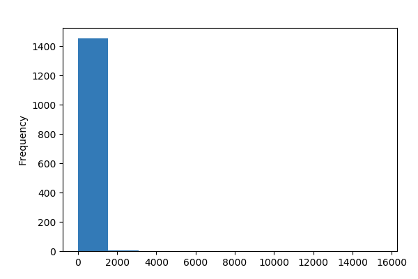

**Common Values**

| Value | Count | Frequency (%) |  |
| --- | --- | --- | --- |
| 0 | 1408 | 96.4% |  |
| 400 | 11 | 0.8% |  |
| 500 | 8 | 0.5% |  |
| 700 | 5 | 0.3% |  |
| 450 | 4 | 0.3% |  |
| 2000 | 4 | 0.3% |  |
| 600 | 4 | 0.3% |  |
| 1200 | 2 | 0.1% |  |
| 480 | 2 | 0.1% |  |
| 1150 | 1 | 0.1% |  |
| Other values (11) | 11 | 0.8% |  |

**Extreme Values**

Minimum 5 values

| Value | Count | Frequency (%) |  |
| --- | --- | --- | --- |
| 0 | 1408 | 96.4% |  |
| 54 | 1 | 0.1% |  |
| 350 | 1 | 0.1% |  |
| 400 | 11 | 0.8% |  |
| 450 | 4 | 0.3% |  |

Maximum 5 values

| Value | Count | Frequency (%) |  |
| --- | --- | --- | --- |
| 2000 | 4 | 0.3% |  |
| 2500 | 1 | 0.1% |  |
| 3500 | 1 | 0.1% |  |
| 8300 | 1 | 0.1% |  |
| 15500 | 1 | 0.1% |  |

MoSold  
Numeric

| Distinct count | 12 |
| --- | --- |
| Unique (%) | 0.8% |
| Missing (%) | 0.0% |
| Missing (n) | 0 |
| Infinite (%) | 0.0% |
| Infinite (n) | 0 |

| Mean | 6.3219 |
| --- | --- |
| Minimum | 1 |
| Maximum | 12 |
| Zeros (%) | 0.0% |

Toggle details

**Statistics**

Quantile statistics

| Minimum | 1 |
| --- | --- |
| 5-th percentile | 2 |
| Q1 | 5 |
| Median | 6 |
| Q3 | 8 |
| 95-th percentile | 11 |
| Maximum | 12 |
| Range | 11 |
| Interquartile range | 3 |

Descriptive statistics

| Standard deviation | 2.7036 |
| --- | --- |
| Coef of variation | 0.42766 |
| Kurtosis | -0.40411 |
| Mean | 6.3219 |
| MAD | 2.1425 |
| Skewness | 0.21205 |
| Sum | 9230 |
| Variance | 7.3096 |
| Memory size | 11.5 KiB |

**Histogram**

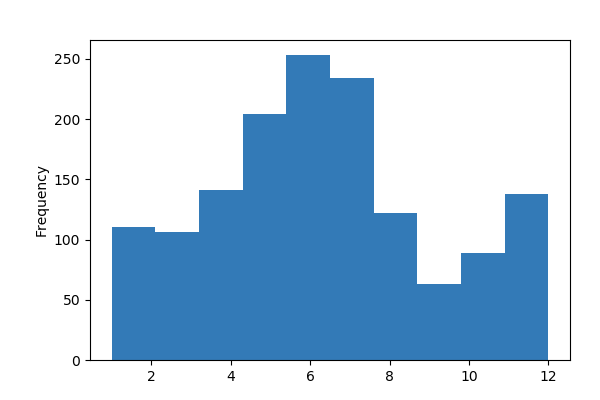

**Common Values**

| Value | Count | Frequency (%) |  |
| --- | --- | --- | --- |
| 6 | 253 | 17.3% |  |
| 7 | 234 | 16.0% |  |
| 5 | 204 | 14.0% |  |
| 4 | 141 | 9.7% |  |
| 8 | 122 | 8.4% |  |
| 3 | 106 | 7.3% |  |
| 10 | 89 | 6.1% |  |
| 11 | 79 | 5.4% |  |
| 9 | 63 | 4.3% |  |
| 12 | 59 | 4.0% |  |
| Other values (2) | 110 | 7.5% |  |

**Extreme Values**

Minimum 5 values

| Value | Count | Frequency (%) |  |
| --- | --- | --- | --- |
| 1 | 58 | 4.0% |  |
| 2 | 52 | 3.6% |  |
| 3 | 106 | 7.3% |  |
| 4 | 141 | 9.7% |  |
| 5 | 204 | 14.0% |  |

Maximum 5 values

| Value | Count | Frequency (%) |  |
| --- | --- | --- | --- |
| 8 | 122 | 8.4% |  |
| 9 | 63 | 4.3% |  |
| 10 | 89 | 6.1% |  |
| 11 | 79 | 5.4% |  |
| 12 | 59 | 4.0% |  |

Neighborhood  
Categorical

| Distinct count | 25 |
| --- | --- |
| Unique (%) | 1.7% |
| Missing (%) | 0.0% |
| Missing (n) | 0 |

| NAmes | 225 |
| --- | --- |
| CollgCr | 150 |
| OldTown | 113 |
| Other values (22) | 972 |

Toggle details

| Value | Count | Frequency (%) |  |
| --- | --- | --- | --- |
| NAmes | 225 | 15.4% |  |
| CollgCr | 150 | 10.3% |  |
| OldTown | 113 | 7.7% |  |
| Edwards | 100 | 6.8% |  |
| Somerst | 86 | 5.9% |  |
| Gilbert | 79 | 5.4% |  |
| NridgHt | 77 | 5.3% |  |
| Sawyer | 74 | 5.1% |  |
| NWAmes | 73 | 5.0% |  |
| SawyerW | 59 | 4.0% |  |
| Other values (15) | 424 | 29.0% |  |

OpenPorchSF  
Numeric

| Distinct count | 202 |
| --- | --- |
| Unique (%) | 13.8% |
| Missing (%) | 0.0% |
| Missing (n) | 0 |
| Infinite (%) | 0.0% |
| Infinite (n) | 0 |

| Mean | 46.66 |
| --- | --- |
| Minimum | 0 |
| Maximum | 547 |
| Zeros (%) | 44.9% |

Toggle details

**Statistics**

Quantile statistics

| Minimum | 0 |
| --- | --- |
| 5-th percentile | 0 |
| Q1 | 0 |
| Median | 25 |
| Q3 | 68 |
| 95-th percentile | 175.05 |
| Maximum | 547 |
| Range | 547 |
| Interquartile range | 68 |

Descriptive statistics

| Standard deviation | 66.256 |
| --- | --- |
| Coef of variation | 1.42 |
| Kurtosis | 8.4903 |
| Mean | 46.66 |
| MAD | 47.678 |
| Skewness | 2.3643 |
| Sum | 68124 |
| Variance | 4389.9 |
| Memory size | 11.5 KiB |

**Histogram**

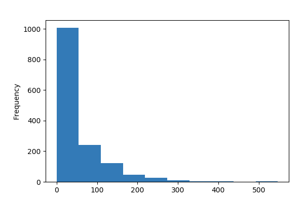

**Common Values**

| Value | Count | Frequency (%) |  |
| --- | --- | --- | --- |
| 0 | 656 | 44.9% |  |
| 36 | 29 | 2.0% |  |
| 48 | 22 | 1.5% |  |
| 20 | 21 | 1.4% |  |
| 40 | 19 | 1.3% |  |
| 45 | 19 | 1.3% |  |
| 30 | 16 | 1.1% |  |
| 24 | 16 | 1.1% |  |
| 60 | 15 | 1.0% |  |
| 39 | 14 | 1.0% |  |
| Other values (192) | 633 | 43.4% |  |

**Extreme Values**

Minimum 5 values

| Value | Count | Frequency (%) |  |
| --- | --- | --- | --- |
| 0 | 656 | 44.9% |  |
| 4 | 1 | 0.1% |  |
| 8 | 1 | 0.1% |  |
| 10 | 1 | 0.1% |  |
| 11 | 1 | 0.1% |  |

Maximum 5 values

| Value | Count | Frequency (%) |  |
| --- | --- | --- | --- |
| 406 | 1 | 0.1% |  |
| 418 | 1 | 0.1% |  |
| 502 | 1 | 0.1% |  |
| 523 | 1 | 0.1% |  |
| 547 | 1 | 0.1% |  |

OverallCond  
Numeric

| Distinct count | 9 |
| --- | --- |
| Unique (%) | 0.6% |
| Missing (%) | 0.0% |
| Missing (n) | 0 |
| Infinite (%) | 0.0% |
| Infinite (n) | 0 |

| Mean | 5.5753 |
| --- | --- |
| Minimum | 1 |
| Maximum | 9 |
| Zeros (%) | 0.0% |

Toggle details

**Statistics**

Quantile statistics

| Minimum | 1 |
| --- | --- |
| 5-th percentile | 4 |
| Q1 | 5 |
| Median | 5 |
| Q3 | 6 |
| 95-th percentile | 8 |
| Maximum | 9 |
| Range | 8 |
| Interquartile range | 1 |

Descriptive statistics

| Standard deviation | 1.1128 |
| --- | --- |
| Coef of variation | 0.19959 |
| Kurtosis | 1.1064 |
| Mean | 5.5753 |
| MAD | 0.88902 |
| Skewness | 0.69307 |
| Sum | 8140 |
| Variance | 1.2383 |
| Memory size | 11.5 KiB |

**Histogram**

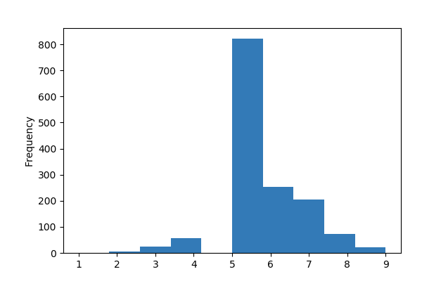

**Common Values**

| Value | Count | Frequency (%) |  |
| --- | --- | --- | --- |
| 5 | 821 | 56.2% |  |
| 6 | 252 | 17.3% |  |
| 7 | 205 | 14.0% |  |
| 8 | 72 | 4.9% |  |
| 4 | 57 | 3.9% |  |
| 3 | 25 | 1.7% |  |
| 9 | 22 | 1.5% |  |
| 2 | 5 | 0.3% |  |
| 1 | 1 | 0.1% |  |

**Extreme Values**

Minimum 5 values

| Value | Count | Frequency (%) |  |
| --- | --- | --- | --- |
| 1 | 1 | 0.1% |  |
| 2 | 5 | 0.3% |  |
| 3 | 25 | 1.7% |  |
| 4 | 57 | 3.9% |  |
| 5 | 821 | 56.2% |  |

Maximum 5 values

| Value | Count | Frequency (%) |  |
| --- | --- | --- | --- |
| 5 | 821 | 56.2% |  |
| 6 | 252 | 17.3% |  |
| 7 | 205 | 14.0% |  |
| 8 | 72 | 4.9% |  |
| 9 | 22 | 1.5% |  |

OverallQual  
Numeric

| Distinct count | 10 |
| --- | --- |
| Unique (%) | 0.7% |
| Missing (%) | 0.0% |
| Missing (n) | 0 |
| Infinite (%) | 0.0% |
| Infinite (n) | 0 |

| Mean | 6.0993 |
| --- | --- |
| Minimum | 1 |
| Maximum | 10 |
| Zeros (%) | 0.0% |

Toggle details

**Statistics**

Quantile statistics

| Minimum | 1 |
| --- | --- |
| 5-th percentile | 4 |
| Q1 | 5 |
| Median | 6 |
| Q3 | 7 |
| 95-th percentile | 8 |
| Maximum | 10 |
| Range | 9 |
| Interquartile range | 2 |

Descriptive statistics

| Standard deviation | 1.383 |
| --- | --- |
| Coef of variation | 0.22675 |
| Kurtosis | 0.096293 |
| Mean | 6.0993 |
| MAD | 1.098 |
| Skewness | 0.21694 |
| Sum | 8905 |
| Variance | 1.9127 |
| Memory size | 11.5 KiB |

**Histogram**

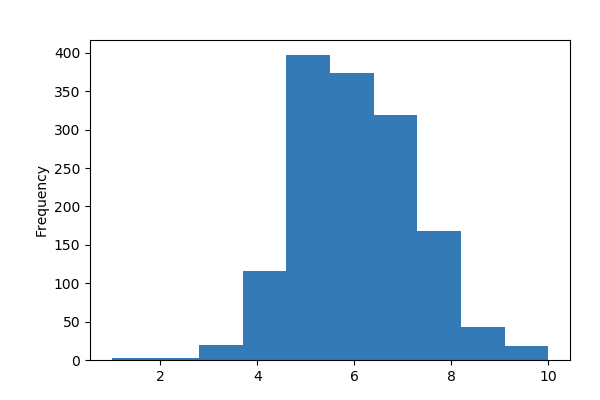

**Common Values**

| Value | Count | Frequency (%) |  |
| --- | --- | --- | --- |
| 5 | 397 | 27.2% |  |
| 6 | 374 | 25.6% |  |
| 7 | 319 | 21.8% |  |
| 8 | 168 | 11.5% |  |
| 4 | 116 | 7.9% |  |
| 9 | 43 | 2.9% |  |
| 3 | 20 | 1.4% |  |
| 10 | 18 | 1.2% |  |
| 2 | 3 | 0.2% |  |
| 1 | 2 | 0.1% |  |

**Extreme Values**

Minimum 5 values

| Value | Count | Frequency (%) |  |
| --- | --- | --- | --- |
| 1 | 2 | 0.1% |  |
| 2 | 3 | 0.2% |  |
| 3 | 20 | 1.4% |  |
| 4 | 116 | 7.9% |  |
| 5 | 397 | 27.2% |  |

Maximum 5 values

| Value | Count | Frequency (%) |  |
| --- | --- | --- | --- |
| 6 | 374 | 25.6% |  |
| 7 | 319 | 21.8% |  |
| 8 | 168 | 11.5% |  |
| 9 | 43 | 2.9% |  |
| 10 | 18 | 1.2% |  |

PavedDrive  
Categorical

| Distinct count | 3 |
| --- | --- |
| Unique (%) | 0.2% |
| Missing (%) | 0.0% |
| Missing (n) | 0 |

| Y | 1340 |
| --- | --- |
| N | 90 |
| P | 30 |

Toggle details

| Value | Count | Frequency (%) |  |
| --- | --- | --- | --- |
| Y | 1340 | 91.8% |  |
| N | 90 | 6.2% |  |
| P | 30 | 2.1% |  |

PoolArea  
Numeric

| Distinct count | 8 |
| --- | --- |
| Unique (%) | 0.5% |
| Missing (%) | 0.0% |
| Missing (n) | 0 |
| Infinite (%) | 0.0% |
| Infinite (n) | 0 |

| Mean | 2.7589 |
| --- | --- |
| Minimum | 0 |
| Maximum | 738 |
| Zeros (%) | 99.5% |

Toggle details

**Statistics**

Quantile statistics

| Minimum | 0 |
| --- | --- |
| 5-th percentile | 0 |
| Q1 | 0 |
| Median | 0 |
| Q3 | 0 |
| 95-th percentile | 0 |
| Maximum | 738 |
| Range | 738 |
| Interquartile range | 0 |

Descriptive statistics

| Standard deviation | 40.177 |
| --- | --- |
| Coef of variation | 14.563 |
| Kurtosis | 223.27 |
| Mean | 2.7589 |
| MAD | 5.4914 |
| Skewness | 14.828 |
| Sum | 4028 |
| Variance | 1614.2 |
| Memory size | 11.5 KiB |

**Histogram**

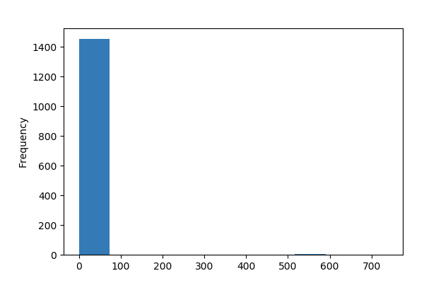

**Common Values**

| Value | Count | Frequency (%) |  |
| --- | --- | --- | --- |
| 0 | 1453 | 99.5% |  |
| 738 | 1 | 0.1% |  |
| 648 | 1 | 0.1% |  |
| 576 | 1 | 0.1% |  |
| 555 | 1 | 0.1% |  |
| 519 | 1 | 0.1% |  |
| 512 | 1 | 0.1% |  |
| 480 | 1 | 0.1% |  |

**Extreme Values**

Minimum 5 values

| Value | Count | Frequency (%) |  |
| --- | --- | --- | --- |
| 0 | 1453 | 99.5% |  |
| 480 | 1 | 0.1% |  |
| 512 | 1 | 0.1% |  |
| 519 | 1 | 0.1% |  |
| 555 | 1 | 0.1% |  |

Maximum 5 values

| Value | Count | Frequency (%) |  |
| --- | --- | --- | --- |
| 519 | 1 | 0.1% |  |
| 555 | 1 | 0.1% |  |
| 576 | 1 | 0.1% |  |
| 648 | 1 | 0.1% |  |
| 738 | 1 | 0.1% |  |

PoolQC  
Categorical

| Distinct count | 4 |
| --- | --- |
| Unique (%) | 0.3% |
| Missing (%) | 99.5% |
| Missing (n) | 1453 |

| Gd | 3 |
| --- | --- |
| Fa | 2 |
| Ex | 2 |
| (Missing) | 1453 |

Toggle details

| Value | Count | Frequency (%) |  |
| --- | --- | --- | --- |
| Gd | 3 | 0.2% |  |
| Fa | 2 | 0.1% |  |
| Ex | 2 | 0.1% |  |
| (Missing) | 1453 | 99.5% |  |

RoofMatl  
Categorical

| Distinct count | 8 |
| --- | --- |
| Unique (%) | 0.5% |
| Missing (%) | 0.0% |
| Missing (n) | 0 |

| CompShg | 1434 |
| --- | --- |
| Tar&Grv | 11 |
| WdShngl | 6 |
| Other values (5) | 9 |

Toggle details

| Value | Count | Frequency (%) |  |
| --- | --- | --- | --- |
| CompShg | 1434 | 98.2% |  |
| Tar&Grv | 11 | 0.8% |  |
| WdShngl | 6 | 0.4% |  |
| WdShake | 5 | 0.3% |  |
| ClyTile | 1 | 0.1% |  |
| Roll | 1 | 0.1% |  |
| Membran | 1 | 0.1% |  |
| Metal | 1 | 0.1% |  |

RoofStyle  
Categorical

| Distinct count | 6 |
| --- | --- |
| Unique (%) | 0.4% |
| Missing (%) | 0.0% |
| Missing (n) | 0 |

| Gable | 1141 |
| --- | --- |
| Hip | 286 |
| Flat | 13 |
| Other values (3) | 20 |

Toggle details

| Value | Count | Frequency (%) |  |
| --- | --- | --- | --- |
| Gable | 1141 | 78.2% |  |
| Hip | 286 | 19.6% |  |
| Flat | 13 | 0.9% |  |
| Gambrel | 11 | 0.8% |  |
| Mansard | 7 | 0.5% |  |
| Shed | 2 | 0.1% |  |

SaleCondition  
Categorical

| Distinct count | 6 |
| --- | --- |
| Unique (%) | 0.4% |
| Missing (%) | 0.0% |
| Missing (n) | 0 |

| Normal | 1198 |
| --- | --- |
| Partial | 125 |
| Abnorml | 101 |
| Other values (3) | 36 |

Toggle details

| Value | Count | Frequency (%) |  |
| --- | --- | --- | --- |
| Normal | 1198 | 82.1% |  |
| Partial | 125 | 8.6% |  |
| Abnorml | 101 | 6.9% |  |
| Family | 20 | 1.4% |  |
| Alloca | 12 | 0.8% |  |
| AdjLand | 4 | 0.3% |  |

SalePrice  
Numeric

| Distinct count | 663 |
| --- | --- |
| Unique (%) | 45.4% |
| Missing (%) | 0.0% |
| Missing (n) | 0 |
| Infinite (%) | 0.0% |
| Infinite (n) | 0 |

| Mean | 180920 |
| --- | --- |
| Minimum | 34900 |
| Maximum | 755000 |
| Zeros (%) | 0.0% |

Toggle details

**Statistics**

Quantile statistics

| Minimum | 34900 |
| --- | --- |
| 5-th percentile | 88000 |
| Q1 | 129980 |
| Median | 163000 |
| Q3 | 214000 |
| 95-th percentile | 326100 |
| Maximum | 755000 |
| Range | 720100 |
| Interquartile range | 84025 |

Descriptive statistics

| Standard deviation | 79443 |
| --- | --- |
| Coef of variation | 0.4391 |
| Kurtosis | 6.5363 |
| Mean | 180920 |
| MAD | 57435 |
| Skewness | 1.8829 |
| Sum | 264144946 |
| Variance | 6311100000 |
| Memory size | 11.5 KiB |

**Histogram**

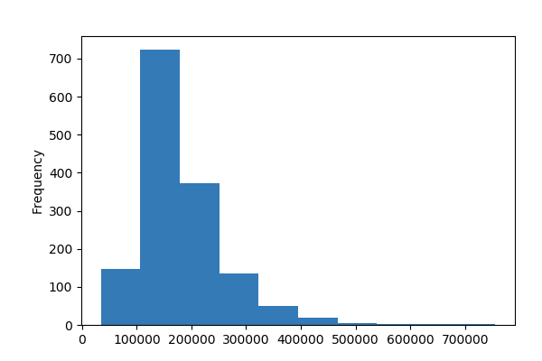

**Common Values**

| Value | Count | Frequency (%) |  |
| --- | --- | --- | --- |
| 140000 | 20 | 1.4% |  |
| 135000 | 17 | 1.2% |  |
| 145000 | 14 | 1.0% |  |
| 155000 | 14 | 1.0% |  |
| 190000 | 13 | 0.9% |  |
| 110000 | 13 | 0.9% |  |
| 160000 | 12 | 0.8% |  |
| 115000 | 12 | 0.8% |  |
| 139000 | 11 | 0.8% |  |
| 130000 | 11 | 0.8% |  |
| Other values (653) | 1323 | 90.6% |  |

**Extreme Values**

Minimum 5 values

| Value | Count | Frequency (%) |  |
| --- | --- | --- | --- |
| 34900 | 1 | 0.1% |  |
| 35311 | 1 | 0.1% |  |
| 37900 | 1 | 0.1% |  |
| 39300 | 1 | 0.1% |  |
| 40000 | 1 | 0.1% |  |

Maximum 5 values

| Value | Count | Frequency (%) |  |
| --- | --- | --- | --- |
| 582933 | 1 | 0.1% |  |
| 611657 | 1 | 0.1% |  |
| 625000 | 1 | 0.1% |  |
| 745000 | 1 | 0.1% |  |
| 755000 | 1 | 0.1% |  |

SaleType  
Categorical

| Distinct count | 9 |
| --- | --- |
| Unique (%) | 0.6% |
| Missing (%) | 0.0% |
| Missing (n) | 0 |

| WD | 1267 |
| --- | --- |
| New | 122 |
| COD | 43 |
| Other values (6) | 28 |

Toggle details

| Value | Count | Frequency (%) |  |
| --- | --- | --- | --- |
| WD | 1267 | 86.8% |  |
| New | 122 | 8.4% |  |
| COD | 43 | 2.9% |  |
| ConLD | 9 | 0.6% |  |
| ConLw | 5 | 0.3% |  |
| ConLI | 5 | 0.3% |  |
| CWD | 4 | 0.3% |  |
| Oth | 3 | 0.2% |  |
| Con | 2 | 0.1% |  |

ScreenPorch  
Numeric

| Distinct count | 76 |
| --- | --- |
| Unique (%) | 5.2% |
| Missing (%) | 0.0% |
| Missing (n) | 0 |
| Infinite (%) | 0.0% |
| Infinite (n) | 0 |

| Mean | 15.061 |
| --- | --- |
| Minimum | 0 |
| Maximum | 480 |
| Zeros (%) | 92.1% |

Toggle details

**Statistics**

Quantile statistics

| Minimum | 0 |
| --- | --- |
| 5-th percentile | 0 |
| Q1 | 0 |
| Median | 0 |
| Q3 | 0 |
| 95-th percentile | 160 |
| Maximum | 480 |
| Range | 480 |
| Interquartile range | 0 |

Descriptive statistics

| Standard deviation | 55.757 |
| --- | --- |
| Coef of variation | 3.7021 |
| Kurtosis | 18.439 |
| Mean | 15.061 |
| MAD | 27.729 |
| Skewness | 4.1222 |
| Sum | 21989 |
| Variance | 3108.9 |
| Memory size | 11.5 KiB |

**Histogram**

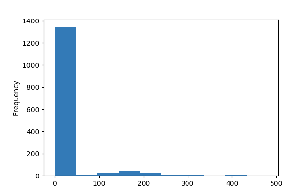

**Common Values**

| Value | Count | Frequency (%) |  |
| --- | --- | --- | --- |
| 0 | 1344 | 92.1% |  |
| 192 | 6 | 0.4% |  |
| 224 | 5 | 0.3% |  |
| 120 | 5 | 0.3% |  |
| 189 | 4 | 0.3% |  |
| 180 | 4 | 0.3% |  |
| 160 | 3 | 0.2% |  |
| 168 | 3 | 0.2% |  |
| 144 | 3 | 0.2% |  |
| 126 | 3 | 0.2% |  |
| Other values (66) | 80 | 5.5% |  |

**Extreme Values**

Minimum 5 values

| Value | Count | Frequency (%) |  |
| --- | --- | --- | --- |
| 0 | 1344 | 92.1% |  |
| 40 | 1 | 0.1% |  |
| 53 | 1 | 0.1% |  |
| 60 | 1 | 0.1% |  |
| 63 | 1 | 0.1% |  |

Maximum 5 values

| Value | Count | Frequency (%) |  |
| --- | --- | --- | --- |
| 385 | 1 | 0.1% |  |
| 396 | 1 | 0.1% |  |
| 410 | 1 | 0.1% |  |
| 440 | 1 | 0.1% |  |
| 480 | 1 | 0.1% |  |

Street  
Categorical

| Distinct count | 2 |
| --- | --- |
| Unique (%) | 0.1% |
| Missing (%) | 0.0% |
| Missing (n) | 0 |

| Pave | 1454 |
| --- | --- |
| Grvl | 6 |

Toggle details

| Value | Count | Frequency (%) |  |
| --- | --- | --- | --- |
| Pave | 1454 | 99.6% |  |
| Grvl | 6 | 0.4% |  |

TotRmsAbvGrd  
Numeric

| Distinct count | 12 |
| --- | --- |
| Unique (%) | 0.8% |
| Missing (%) | 0.0% |
| Missing (n) | 0 |
| Infinite (%) | 0.0% |
| Infinite (n) | 0 |

| Mean | 6.5178 |
| --- | --- |
| Minimum | 2 |
| Maximum | 14 |
| Zeros (%) | 0.0% |

Toggle details

**Statistics**

Quantile statistics

| Minimum | 2 |
| --- | --- |
| 5-th percentile | 4 |
| Q1 | 5 |
| Median | 6 |
| Q3 | 7 |
| 95-th percentile | 10 |
| Maximum | 14 |
| Range | 12 |
| Interquartile range | 2 |

Descriptive statistics

| Standard deviation | 1.6254 |
| --- | --- |
| Coef of variation | 0.24938 |
| Kurtosis | 0.88076 |
| Mean | 6.5178 |
| MAD | 1.2796 |
| Skewness | 0.67634 |
| Sum | 9516 |
| Variance | 2.6419 |
| Memory size | 11.5 KiB |

**Histogram**

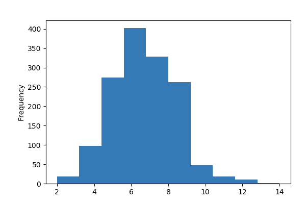

**Common Values**

| Value | Count | Frequency (%) |  |
| --- | --- | --- | --- |
| 6 | 402 | 27.5% |  |
| 7 | 329 | 22.5% |  |
| 5 | 275 | 18.8% |  |
| 8 | 187 | 12.8% |  |
| 4 | 97 | 6.6% |  |
| 9 | 75 | 5.1% |  |
| 10 | 47 | 3.2% |  |
| 11 | 18 | 1.2% |  |
| 3 | 17 | 1.2% |  |
| 12 | 11 | 0.8% |  |
| Other values (2) | 2 | 0.1% |  |

**Extreme Values**

Minimum 5 values

| Value | Count | Frequency (%) |  |
| --- | --- | --- | --- |
| 2 | 1 | 0.1% |  |
| 3 | 17 | 1.2% |  |
| 4 | 97 | 6.6% |  |
| 5 | 275 | 18.8% |  |
| 6 | 402 | 27.5% |  |

Maximum 5 values

| Value | Count | Frequency (%) |  |
| --- | --- | --- | --- |
| 9 | 75 | 5.1% |  |
| 10 | 47 | 3.2% |  |
| 11 | 18 | 1.2% |  |
| 12 | 11 | 0.8% |  |
| 14 | 1 | 0.1% |  |

TotalBsmtSF  
Numeric

| Distinct count | 721 |
| --- | --- |
| Unique (%) | 49.4% |
| Missing (%) | 0.0% |
| Missing (n) | 0 |
| Infinite (%) | 0.0% |
| Infinite (n) | 0 |

| Mean | 1057.4 |
| --- | --- |
| Minimum | 0 |
| Maximum | 6110 |
| Zeros (%) | 2.5% |

Toggle details

**Statistics**

Quantile statistics

| Minimum | 0 |
| --- | --- |
| 5-th percentile | 519.3 |
| Q1 | 795.75 |
| Median | 991.5 |
| Q3 | 1298.2 |
| 95-th percentile | 1753 |
| Maximum | 6110 |
| Range | 6110 |
| Interquartile range | 502.5 |

Descriptive statistics

| Standard deviation | 438.71 |
| --- | --- |
| Coef of variation | 0.41488 |
| Kurtosis | 13.25 |
| Mean | 1057.4 |
| MAD | 321.28 |
| Skewness | 1.5243 |
| Sum | 1543847 |
| Variance | 192460 |
| Memory size | 11.5 KiB |

**Histogram**

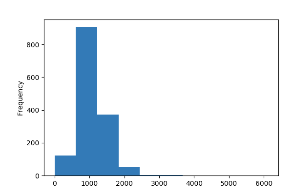

**Common Values**

| Value | Count | Frequency (%) |  |
| --- | --- | --- | --- |
| 0 | 37 | 2.5% |  |
| 864 | 35 | 2.4% |  |
| 672 | 17 | 1.2% |  |
| 912 | 15 | 1.0% |  |
| 1040 | 14 | 1.0% |  |
| 816 | 13 | 0.9% |  |
| 728 | 12 | 0.8% |  |
| 768 | 12 | 0.8% |  |
| 848 | 11 | 0.8% |  |
| 780 | 11 | 0.8% |  |
| Other values (711) | 1283 | 87.9% |  |

**Extreme Values**

Minimum 5 values

| Value | Count | Frequency (%) |  |
| --- | --- | --- | --- |
| 0 | 37 | 2.5% |  |
| 105 | 1 | 0.1% |  |
| 190 | 1 | 0.1% |  |
| 264 | 3 | 0.2% |  |
| 270 | 1 | 0.1% |  |

Maximum 5 values

| Value | Count | Frequency (%) |  |
| --- | --- | --- | --- |
| 3094 | 1 | 0.1% |  |
| 3138 | 1 | 0.1% |  |
| 3200 | 1 | 0.1% |  |
| 3206 | 1 | 0.1% |  |
| 6110 | 1 | 0.1% |  |

Utilities  
Categorical

| Distinct count | 2 |
| --- | --- |
| Unique (%) | 0.1% |
| Missing (%) | 0.0% |
| Missing (n) | 0 |

| AllPub | 1459 |
| --- | --- |
| NoSeWa | 1 |

Toggle details

| Value | Count | Frequency (%) |  |
| --- | --- | --- | --- |
| AllPub | 1459 | 99.9% |  |
| NoSeWa | 1 | 0.1% |  |

WoodDeckSF  
Numeric

| Distinct count | 274 |
| --- | --- |
| Unique (%) | 18.8% |
| Missing (%) | 0.0% |
| Missing (n) | 0 |
| Infinite (%) | 0.0% |
| Infinite (n) | 0 |

| Mean | 94.245 |
| --- | --- |
| Minimum | 0 |
| Maximum | 857 |
| Zeros (%) | 52.1% |

Toggle details

**Statistics**

Quantile statistics

| Minimum | 0 |
| --- | --- |
| 5-th percentile | 0 |
| Q1 | 0 |
| Median | 0 |
| Q3 | 168 |
| 95-th percentile | 335 |
| Maximum | 857 |
| Range | 857 |
| Interquartile range | 168 |

Descriptive statistics

| Standard deviation | 125.34 |
| --- | --- |
| Coef of variation | 1.3299 |
| Kurtosis | 2.993 |
| Mean | 94.245 |
| MAD | 102 |
| Skewness | 1.5414 |
| Sum | 137597 |
| Variance | 15710 |
| Memory size | 11.5 KiB |

**Histogram**

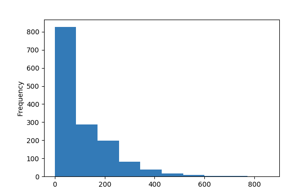

**Common Values**

| Value | Count | Frequency (%) |  |
| --- | --- | --- | --- |
| 0 | 761 | 52.1% |  |
| 192 | 38 | 2.6% |  |
| 100 | 36 | 2.5% |  |
| 144 | 33 | 2.3% |  |
| 120 | 31 | 2.1% |  |
| 168 | 28 | 1.9% |  |
| 140 | 15 | 1.0% |  |
| 224 | 14 | 1.0% |  |
| 240 | 10 | 0.7% |  |
| 208 | 10 | 0.7% |  |
| Other values (264) | 484 | 33.2% |  |

**Extreme Values**

Minimum 5 values

| Value | Count | Frequency (%) |  |
| --- | --- | --- | --- |
| 0 | 761 | 52.1% |  |
| 12 | 2 | 0.1% |  |
| 24 | 2 | 0.1% |  |
| 26 | 2 | 0.1% |  |
| 28 | 2 | 0.1% |  |

Maximum 5 values

| Value | Count | Frequency (%) |  |
| --- | --- | --- | --- |
| 668 | 1 | 0.1% |  |
| 670 | 1 | 0.1% |  |
| 728 | 1 | 0.1% |  |
| 736 | 1 | 0.1% |  |
| 857 | 1 | 0.1% |  |

YearBuilt  
Numeric

| Distinct count | 112 |
| --- | --- |
| Unique (%) | 7.7% |
| Missing (%) | 0.0% |
| Missing (n) | 0 |
| Infinite (%) | 0.0% |
| Infinite (n) | 0 |

| Mean | 1971.3 |
| --- | --- |
| Minimum | 1872 |
| Maximum | 2010 |
| Zeros (%) | 0.0% |

Toggle details

**Statistics**

Quantile statistics

| Minimum | 1872 |
| --- | --- |
| 5-th percentile | 1916 |
| Q1 | 1954 |
| Median | 1973 |
| Q3 | 2000 |
| 95-th percentile | 2007 |
| Maximum | 2010 |
| Range | 138 |
| Interquartile range | 46 |

Descriptive statistics

| Standard deviation | 30.203 |
| --- | --- |
| Coef of variation | 0.015322 |
| Kurtosis | -0.43955 |
| Mean | 1971.3 |
| MAD | 25.067 |
| Skewness | -0.61346 |
| Sum | 2878051 |
| Variance | 912.22 |
| Memory size | 11.5 KiB |

**Histogram**

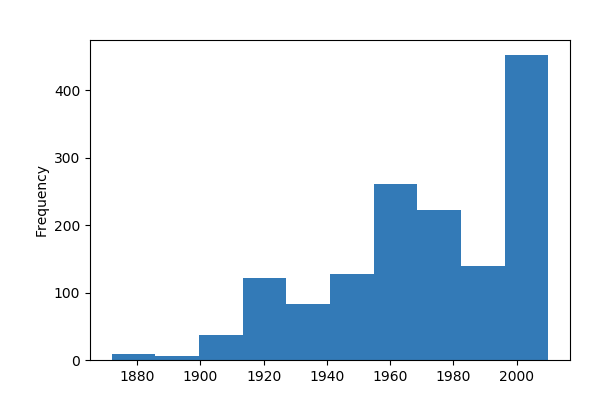

**Common Values**

| Value | Count | Frequency (%) |  |
| --- | --- | --- | --- |
| 2006 | 67 | 4.6% |  |
| 2005 | 64 | 4.4% |  |
| 2004 | 54 | 3.7% |  |
| 2007 | 49 | 3.4% |  |
| 2003 | 45 | 3.1% |  |
| 1976 | 33 | 2.3% |  |
| 1977 | 32 | 2.2% |  |
| 1920 | 30 | 2.1% |  |
| 1959 | 26 | 1.8% |  |
| 1999 | 25 | 1.7% |  |
| Other values (102) | 1035 | 70.9% |  |

**Extreme Values**

Minimum 5 values

| Value | Count | Frequency (%) |  |
| --- | --- | --- | --- |
| 1872 | 1 | 0.1% |  |
| 1875 | 1 | 0.1% |  |
| 1880 | 4 | 0.3% |  |
| 1882 | 1 | 0.1% |  |
| 1885 | 2 | 0.1% |  |

Maximum 5 values

| Value | Count | Frequency (%) |  |
| --- | --- | --- | --- |
| 2006 | 67 | 4.6% |  |
| 2007 | 49 | 3.4% |  |
| 2008 | 23 | 1.6% |  |
| 2009 | 18 | 1.2% |  |
| 2010 | 1 | 0.1% |  |

YearRemodAdd  
Numeric

| Distinct count | 61 |
| --- | --- |
| Unique (%) | 4.2% |
| Missing (%) | 0.0% |
| Missing (n) | 0 |
| Infinite (%) | 0.0% |
| Infinite (n) | 0 |

| Mean | 1984.9 |
| --- | --- |
| Minimum | 1950 |
| Maximum | 2010 |
| Zeros (%) | 0.0% |

Toggle details

**Statistics**

Quantile statistics

| Minimum | 1950 |
| --- | --- |
| 5-th percentile | 1950 |
| Q1 | 1967 |
| Median | 1994 |
| Q3 | 2004 |
| 95-th percentile | 2007 |
| Maximum | 2010 |
| Range | 60 |
| Interquartile range | 37 |

Descriptive statistics

| Standard deviation | 20.645 |
| --- | --- |
| Coef of variation | 0.010401 |
| Kurtosis | -1.2722 |
| Mean | 1984.9 |
| MAD | 18.623 |
| Skewness | -0.50356 |
| Sum | 2897904 |
| Variance | 426.23 |
| Memory size | 11.5 KiB |

**Histogram**

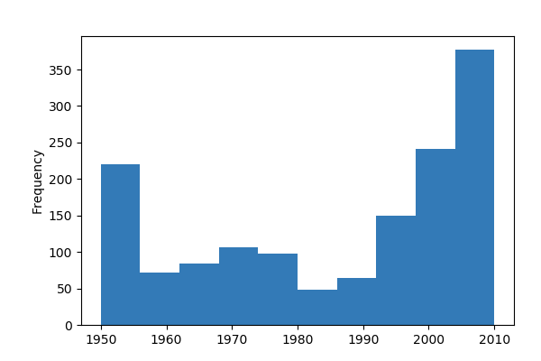

**Common Values**

| Value | Count | Frequency (%) |  |
| --- | --- | --- | --- |
| 1950 | 178 | 12.2% |  |
| 2006 | 97 | 6.6% |  |
| 2007 | 76 | 5.2% |  |
| 2005 | 73 | 5.0% |  |
| 2004 | 62 | 4.2% |  |
| 2000 | 55 | 3.8% |  |
| 2003 | 51 | 3.5% |  |
| 2002 | 48 | 3.3% |  |
| 2008 | 40 | 2.7% |  |
| 1996 | 36 | 2.5% |  |
| Other values (51) | 744 | 51.0% |  |

**Extreme Values**

Minimum 5 values

| Value | Count | Frequency (%) |  |
| --- | --- | --- | --- |
| 1950 | 178 | 12.2% |  |
| 1951 | 4 | 0.3% |  |
| 1952 | 5 | 0.3% |  |
| 1953 | 10 | 0.7% |  |
| 1954 | 14 | 1.0% |  |

Maximum 5 values

| Value | Count | Frequency (%) |  |
| --- | --- | --- | --- |
| 2006 | 97 | 6.6% |  |
| 2007 | 76 | 5.2% |  |
| 2008 | 40 | 2.7% |  |
| 2009 | 23 | 1.6% |  |
| 2010 | 6 | 0.4% |  |

YrSold  
Numeric

| Distinct count | 5 |
| --- | --- |
| Unique (%) | 0.3% |
| Missing (%) | 0.0% |
| Missing (n) | 0 |
| Infinite (%) | 0.0% |
| Infinite (n) | 0 |

| Mean | 2007.8 |
| --- | --- |
| Minimum | 2006 |
| Maximum | 2010 |
| Zeros (%) | 0.0% |

Toggle details

**Statistics**

Quantile statistics

| Minimum | 2006 |
| --- | --- |
| 5-th percentile | 2006 |
| Q1 | 2007 |
| Median | 2008 |
| Q3 | 2009 |
| 95-th percentile | 2010 |
| Maximum | 2010 |
| Range | 4 |
| Interquartile range | 2 |

Descriptive statistics

| Standard deviation | 1.3281 |
| --- | --- |
| Coef of variation | 0.00066146 |
| Kurtosis | -1.1906 |
| Mean | 2007.8 |
| MAD | 1.1487 |
| Skewness | 0.096269 |
| Sum | 2931411 |
| Variance | 1.7638 |
| Memory size | 11.5 KiB |

**Histogram**

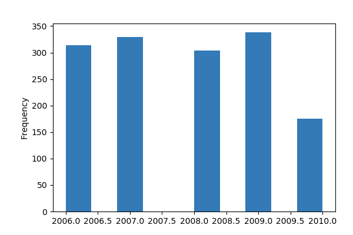

**Common Values**

| Value | Count | Frequency (%) |  |
| --- | --- | --- | --- |
| 2009 | 338 | 23.2% |  |
| 2007 | 329 | 22.5% |  |
| 2006 | 314 | 21.5% |  |
| 2008 | 304 | 20.8% |  |
| 2010 | 175 | 12.0% |  |

**Extreme Values**

Minimum 5 values

| Value | Count | Frequency (%) |  |
| --- | --- | --- | --- |
| 2006 | 314 | 21.5% |  |
| 2007 | 329 | 22.5% |  |
| 2008 | 304 | 20.8% |  |
| 2009 | 338 | 23.2% |  |
| 2010 | 175 | 12.0% |  |

Maximum 5 values

| Value | Count | Frequency (%) |  |
| --- | --- | --- | --- |
| 2006 | 314 | 21.5% |  |
| 2007 | 329 | 22.5% |  |
| 2008 | 304 | 20.8% |  |
| 2009 | 338 | 23.2% |  |
| 2010 | 175 | 12.0% |  |

# Correlations

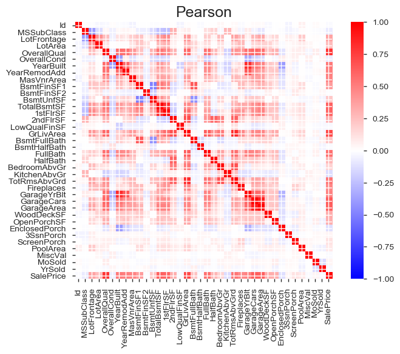

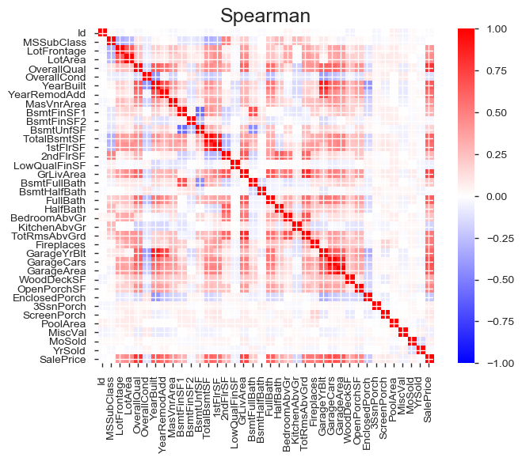

# Sample

|  | Id | MSSubClass | MSZoning | LotFrontage | LotArea | Street | Alley | LotShape | LandContour | Utilities | LotConfig | LandSlope | Neighborhood | Condition1 | Condition2 | BldgType | HouseStyle | OverallQual | OverallCond | YearBuilt | YearRemodAdd | RoofStyle | RoofMatl | Exterior1st | Exterior2nd | MasVnrType | MasVnrArea | ExterQual | ExterCond | … |
| --- | --- | --- | --- | --- | --- | --- | --- | --- | --- | --- | --- | --- | --- | --- | --- | --- | --- | --- | --- | --- | --- | --- | --- | --- | --- | --- | --- | --- | --- | --- |
| 0 | 1 | 60 | RL | 65.0 | 8450 | Pave | NaN | Reg | Lvl | AllPub | Inside | Gtl | CollgCr | Norm | Norm | 1Fam | 2Story | 7 | 5 | 2003 | 2003 | Gable | CompShg | VinylSd | VinylSd | BrkFace | 196.0 | Gd | TA | … |
| 1 | 2 | 20 | RL | 80.0 | 9600 | Pave | NaN | Reg | Lvl | AllPub | FR2 | Gtl | Veenker | Feedr | Norm | 1Fam | 1Story | 6 | 8 | 1976 | 1976 | Gable | CompShg | MetalSd | MetalSd | None | 0.0 | TA | TA | … |
| 2 | 3 | 60 | RL | 68.0 | 11250 | Pave | NaN | IR1 | Lvl | AllPub | Inside | Gtl | CollgCr | Norm | Norm | 1Fam | 2Story | 7 | 5 | 2001 | 2002 | Gable | CompShg | VinylSd | VinylSd | BrkFace | 162.0 | Gd | TA | … |
| 3 | 4 | 70 | RL | 60.0 | 9550 | Pave | NaN | IR1 | Lvl | AllPub | Corner | Gtl | Crawfor | Norm | Norm | 1Fam | 2Story | 7 | 5 | 1915 | 1970 | Gable | CompShg | Wd Sdng | Wd Shng | None | 0.0 | TA | TA | … |
| 4 | 5 | 60 | RL | 84.0 | 14260 | Pave | NaN | IR1 | Lvl | AllPub | FR2 | Gtl | NoRidge | Norm | Norm | 1Fam | 2Story | 8 | 5 | 2000 | 2000 | Gable | CompShg | VinylSd | VinylSd | BrkFace | 350.0 | Gd | TA | … |